# FITB keypress Analysis

2025-1-29

## Packages

```r
# import packages
library(lme4)     # mixed models
library(dplyr)    # dataframe manipulation
library(readr)    # reading in the data
library(emmeans)  # likelihood ratio testing
```

```r
library(purrr)    # for map()
library(lattice)  # for xyplot()
library(TAF)      # setting up output file directory structure during model fitting
library(moments)  # skewness for selecting between additive and multiplicative models of response times
library(stringr)


#If you get an error, you likely need to install the packages using the "install.package('insert-package-name-here')" command
```

## Notebook configurable settings

```r
# name the directories to read data from and write output to
input_version = 9
output_version = 'programming'
program_type = 'short'
```

make an overall output directory (model summaries, stats, etc. will all go here)

```r
#setwd("..")
outputdir = sprintf("%s/../candidate-models/regression-models-%s",getwd(), output_version)
```

```r
mkdir(outputdir)
```

## Loading Data

```r
#setwd("..")
input_file <- sprintf("%s/../preprocessed-data/full-data-version-%d/programming-full-data.csv", getwd(), input_version)
data <- read.csv(input_file)

#Transforming the session number such that it is treated as a character and not a value
data <- transform(data, session = as.character(session))

#data
```

Removing irrelevant data from dataframe

```r
#remove rows that have no values
data <- data[data$duration > 1, ]


#Removing the one participants that didn't listen to instructions:
participants_to_remove <- c("REDACTED_20")
data <- subset(data, !(participant_id %in% participants_to_remove))
```

Looking at FITB and the passed ones only

```r
data <- data[data$problem_type == program_type, ]

data <- data[data$accuracy == 'Pass', ]
```

Centralizing dureciton/reaction times where not normally distrubuted so that were transformed

```r
mean_value <- mean((data$keypress_rate..keypresses.per.second.))
print(mean_value)
```

```
## [1] 1.156609
```

```r
cat('Original skewness:', skewness(data$keypress_rate..keypresses.per.second.))
```

```
## Original skewness: 1.44911
```

```r
cat('Sqrt skewness:', skewness(sqrt(data$keypress_rate..keypresses.per.second.)))
```

```
## Sqrt skewness: 0.5364008
```

```r
cat('Log skewness:', skewness(log(data$keypress_rate..keypresses.per.second.)))
```

```
## Log skewness: -0.5719105
```

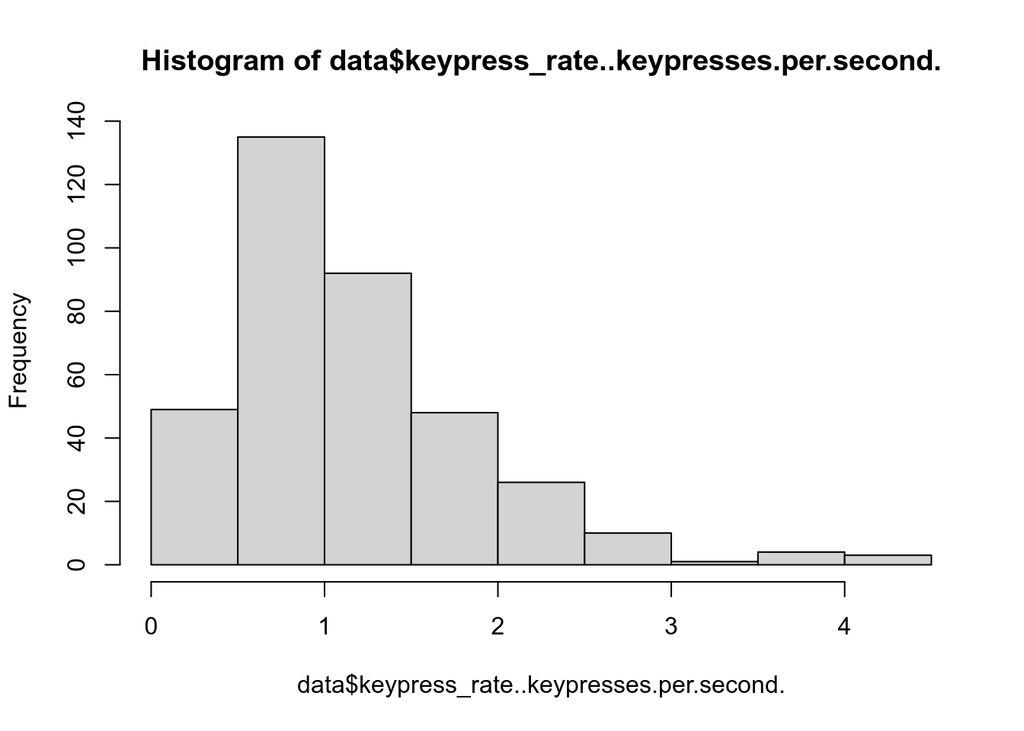

```r
hist(data$keypress_rate..keypresses.per.second.)
```

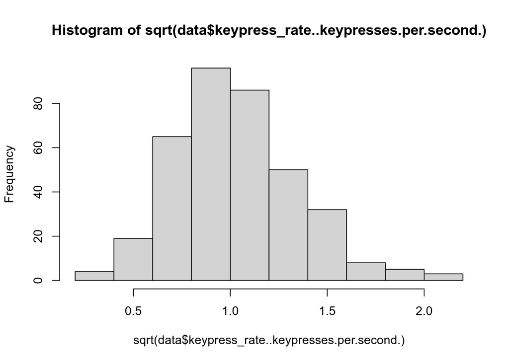

```r
hist(sqrt(data$keypress_rate..keypresses.per.second.))
```

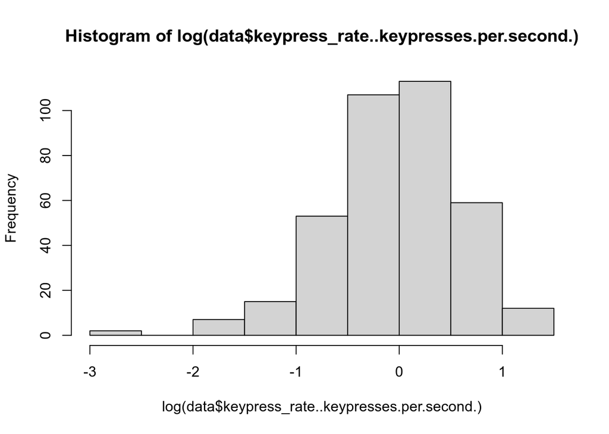

```r
hist(log(data$keypress_rate..keypresses.per.second.))
```

```r
#Make sure you have n=27 participants

id <- unique(data$participant_id)
id #all unique IDs
```

```
##  [1] "REDACTED_0"  "REDACTED_1"  "REDACTED_10" "REDACTED_11" "REDACTED_12"
##  [6] "REDACTED_13" "REDACTED_14" "REDACTED_15" "REDACTED_16" "REDACTED_17"
## [11] "REDACTED_18" "REDACTED_19" "REDACTED_2"  "REDACTED_21" "REDACTED_22"
## [16] "REDACTED_23" "REDACTED_24" "REDACTED_25" "REDACTED_26" "REDACTED_27"
## [21] "REDACTED_3"  "REDACTED_4"  "REDACTED_5"  "REDACTED_6"  "REDACTED_7"
## [26] "REDACTED_8"  "REDACTED_9"
```

```r
length(id) #number of participants
```

```
## [1] 27
```

distribution of number of problems succesffully completed by participants

```r
count_table <- table(data$TMS_Type, data$participant_id)

print(count_table)
```

```
##
##      REDACTED_0 REDACTED_1 REDACTED_10 REDACTED_11 REDACTED_12 REDACTED_13
##   CM         10          6           6          11           3           7
##   WM         10          7           6           7           7           6
##
##      REDACTED_14 REDACTED_15 REDACTED_16 REDACTED_17 REDACTED_18 REDACTED_19
##   CM           5           7           6           6           8           9
##   WM           7           5          10           5           6          10
##
##      REDACTED_2 REDACTED_21 REDACTED_22 REDACTED_23 REDACTED_24 REDACTED_25
##   CM          5           9           7           7           6           6
##   WM          2          10           7           7           4           7
##
##      REDACTED_26 REDACTED_27 REDACTED_3 REDACTED_4 REDACTED_5 REDACTED_6
##   CM          11          10         10          5          8          6
##   WM           7           7          5          5          9          6
##
##      REDACTED_7 REDACTED_8 REDACTED_9
##   CM          0          9          6
##   WM          4          6          7
```

## Select independent variables

1. `participant_id` (person) : random intercept
   - People are drawn from an underlying distribution; we aren’t interested in learning coefficients specific to the members of our sample, but rather in what they tell us about that underlying population. Random effects tell us about the distribution rather than the elements observed.
   - This variable is used to model person-specific attributes, such as a “skill,” translating to overall faster or slower response times, that can be different for each person
2. `problem_id` (question prompt) : random intercept
   - The underlying distribution of stimuli is a little less clear than that of participants. This variable can be thought of as modeling the dispersion of question-specific difficulties.
3. `TMS_Type` (TMS treatment condition, i.e. brain region stimulated) : fixed & random intercepts
   - Based on previous literature, we hypothesize that the brain region stimulated may have an effect that is systematic (i.e. very consistent between people, topics, etc.), quantitatively heterogeneous (i.e. directionally consistent, but widely varying in magnitude), or even a qualitatively heterogeneous (i.e. varying in direction, possibly in conjunction with magnitude). Therefore, we assess the goodness of fit for candidate models containing `TMS_Type` as a fixed effect, random effect, both, or neither, in order to test this hypothesis.
4. `session`and `coding_section_no` (chronological numbering of the session, per participant) : fixed intercept
   - This is used to account for learning/training effect, i.e. participants getting better at test-taking under our specific test instrument over the course of the study. For example, they may become more familiar with the question structure, or become better at recalling old material as they do more practice questions. We expect this to be systematic (uniformly decreasing response time), so we model it as a fixed effect.

## Specify candidate predictor structures for mixed model formulas

```r
fixed_effects <- c(
  # no fixed effects
  "",

  # no interactions
  "TMS_Type",
  "session",
  "coding_section_no",
  "problem_order",
  "problem_set",

  "pain",
  "physical_symptoms",
  "discomfort",
  "sensations",

  "TMS_Type + session",
  "TMS_Type + coding_section_no",
  "TMS_Type + problem_order",
  "TMS_Type + problem_set",
  "session + coding_section_no",
  "session + problem_order",
  "session + problem_set",
  "problem_set + coding_section_no",
  "problem_set + problem_order",
  "coding_section_no + problem_order",

  "TMS_Type + pain",
  "TMS_Type + physical_symptoms",
  "TMS_Type + discomfort",
  "TMS_Type + sensations",
  "session + pain",
  "session + physical_symptoms",
  "session + discomfort",
  "session + sensations",
  "coding_section_no + pain",
  "coding_section_no + physical_symptoms",
  "coding_section_no + discomfort",
  "coding_section_no + sensations",
  "problem_order + pain",
  "problem_order + physical_symptoms",
  "problem_order + discomfort",
  "problem_order + sensations",
  "problem_set + pain",
  "problem_set + physical_symptoms",
  "problem_set + discomfort",
  "problem_set + sensations",

  "TMS_Type + session + coding_section_no + problem_order + problem_set + pain + physical_symptoms + discomfort + sensations",

  # 2-way interactions
  "TMS_Type * session",
  "TMS_Type * coding_section_no",
  "TMS_Type * problem_order",
  "TMS_Type * problem_set",
  "session * coding_section_no",
  "session * problem_order",
  "session * problem_set",
  "problem_set * coding_section_no",
  "problem_set * problem_order",
  "coding_section_no * problem_order",

  "TMS_Type * pain",
  "TMS_Type * physical_symptoms",
  "TMS_Type * discomfort",
  "TMS_Type * sensations",
  "session * pain",
  "session * physical_symptoms",
  "session * discomfort",
  "session * sensations",
  "coding_section_no * pain",
  "coding_section_no * physical_symptoms",
  "coding_section_no * discomfort",
  "coding_section_no * sensations",
  "problem_order * pain",
  "problem_order * physical_symptoms",
  "problem_order * discomfort",
  "problem_order * sensations",
  "problem_set * pain",
  "problem_set * physical_symptoms",
  "problem_set * discomfort",
  "problem_set * sensations",

  # 1- and 2-way interactions
  "TMS_Type * session + problem_set + coding_section_no + problem_order + pain + physical_symptoms + discomfort + sensations",
  "TMS_Type * problem_set + session + coding_section_no + problem_order + pain + physical_symptoms + discomfort + sensations",
  "TMS_Type * coding_section_no + session + problem_set + problem_order + pain + physical_symptoms + discomfort + sensations",
  "TMS_Type * problem_order + session + problem_set + coding_section_no + pain + physical_symptoms + discomfort + sensations",
  "session * problem_set + TMS_Type + coding_section_no + problem_order + pain + physical_symptoms + discomfort + sensations",
  "session * coding_section_no + TMS_Type + problem_set + problem_order + pain + physical_symptoms + discomfort + sensations",
  "session * problem_order + TMS_Type + problem_set + coding_section_no + pain + physical_symptoms + discomfort + sensations",
  "problem_set * coding_section_no + TMS_Type + session + problem_order + pain + physical_symptoms + discomfort + sensations",
  "problem_set * problem_order + TMS_Type + session + coding_section_no + pain + physical_symptoms + discomfort + sensations",
  "coding_section_no * problem_order + TMS_Type + session + problem_set + pain + physical_symptoms + discomfort + sensations",

  "TMS_Type * pain + session + problem_set + coding_section_no + problem_order",
  "TMS_Type * physical_symptoms + session + problem_set + coding_section_no + problem_order",
  "TMS_Type * discomfort + session + problem_set + coding_section_no + problem_order",
  "TMS_Type * sensations + session + problem_set + coding_section_no + problem_order",

  # multiple 2-way interactions
  "TMS_Type * session + problem_set * coding_section_no + problem_order + pain + physical_symptoms + discomfort + sensations",
  "TMS_Type * session + problem_set * problem_order + coding_section_no + pain + physical_symptoms + discomfort + sensations",
  "TMS_Type * session + coding_section_no * problem_order + problem_set + pain + physical_symptoms + discomfort + sensations",
  "TMS_Type * problem_set + session * coding_section_no + problem_order + pain + physical_symptoms + discomfort + sensations",
  "TMS_Type * problem_set + session * problem_order + coding_section_no + pain + physical_symptoms + discomfort + sensations",
  "TMS_Type * problem_set + coding_section_no * problem_order + session + pain + physical_symptoms + discomfort + sensations",
  "TMS_Type * coding_section_no + session * problem_set + problem_order + pain + physical_symptoms + discomfort + sensations",
  "TMS_Type * coding_section_no + session * problem_order + problem_set + pain + physical_symptoms + discomfort + sensations",
  "TMS_Type * coding_section_no + problem_set * problem_order + session + pain + physical_symptoms + discomfort + sensations",
  "TMS_Type * problem_order + session * problem_set + coding_section_no + pain + physical_symptoms + discomfort + sensations",
  "TMS_Type * problem_order + session * coding_section_no + problem_set + pain + physical_symptoms + discomfort + sensations",
  "TMS_Type * problem_order + problem_set * coding_section_no + session + pain + physical_symptoms + discomfort + sensations",
  "session * problem_set + coding_section_no * problem_order + TMS_Type + pain + physical_symptoms + discomfort + sensations",
  "session * coding_section_no + problem_set * problem_order + TMS_Type + pain + physical_symptoms + discomfort + sensations",
  "session * problem_order + problem_set * coding_section_no + TMS_Type + pain + physical_symptoms + discomfort + sensations",

  # 3-way interactions
  "TMS_Type * session * problem_set + coding_section_no + problem_order + pain + physical_symptoms + discomfort + sensations",
  "TMS_Type * session * coding_section_no + problem_set + problem_order + pain + physical_symptoms + discomfort + sensations",
  "TMS_Type * session * problem_order + problem_set + coding_section_no + pain + physical_symptoms + discomfort + sensations",
  "TMS_Type * problem_set * coding_section_no + problem_order + session + pain + physical_symptoms + discomfort + sensations",
  "TMS_Type * problem_set * problem_order + coding_section_no + session + pain + physical_symptoms + discomfort + sensations",
  "TMS_Type * coding_section_no * problem_order + session + problem_set + pain + physical_symptoms + discomfort + sensations",
  "session * problem_set * coding_section_no + problem_order + TMS_Type + pain + physical_symptoms + discomfort + sensations",
  "session * problem_set * problem_order + coding_section_no + TMS_Type + pain + physical_symptoms + discomfort + sensations",
  "session * coding_section_no * problem_order + TMS_Type + problem_set + pain + physical_symptoms + discomfort + sensations",
  "problem_set * coding_section_no * problem_order + TMS_Type + session + pain + physical_symptoms + discomfort + sensations"
)
```

```r
random_effects <- c(
  #"",                               # (1)
  "participant_id",
  "problem_id",
  "participant_id:TMS_Type",
  "problem_id:TMS_Type"
)
```

In this first cell, we enumerate random effect structures by taking all combinations of the random effects specified.

```r
random_effects = map(random_effects, function (s) sprintf("(1|%s)", s))

random_exprs = c()
N_random = length(random_effects)
for (k in 1:N_random) {
  iii = combn(1:N_random, k, simplify=FALSE)
  for (ii in iii) {
    expr = paste(random_effects[ii], collapse = " + ")
    random_exprs = append(random_exprs, expr)
  }
}
```

Now, we combine the response variable, fixed effects, and random effects together to generate our candidate model structures.

```r
sqrtlinear_formulae = c()
for (fe in fixed_effects) {
  for (re in random_exprs) {
    f = ""
    if (fe == "") {
      f = sprintf("sqrt(keypress_rate..keypresses.per.second.) ~ %s", re)
    } else {
      f = sprintf("sqrt(keypress_rate..keypresses.per.second.) ~ %s + %s", fe, re)
    }
    sqrtlinear_formulae = append(sqrtlinear_formulae, f)
  }
}

print(length(sqrtlinear_formulae))
```

```
## [1] 1650
```

Filter out invalid model specifications

```r
# generate all the boolean index vectors

# formulas with TMS fixed effect
has_TMS <- grepl('TMS_Type ', sqrtlinear_formulae, fixed = TRUE)

# formulas with participant random effect
has_participant <- grepl('(1|participant_id)', sqrtlinear_formulae, fixed = TRUE)

# formulas with problem random effect
has_problem <- grepl('(1|problem_id)', sqrtlinear_formulae, fixed = TRUE)

# formulas with TMS x participant random effect
has_TMS_participant <- grepl('(1|participant_id:TMS_Type)', sqrtlinear_formulae, fixed = TRUE)

# formulas with TMS x problem random effect
has_TMS_problem <- grepl('(1|problem_id:TMS_Type)', sqrtlinear_formulae, fixed = TRUE)

# remove them

invalid <- (has_TMS_participant & (!has_TMS | !has_participant)) | (has_TMS_problem & (!has_TMS | !has_problem))

invalid_sqrtlinear_formulae <- sqrtlinear_formulae[invalid]
sqrtlinear_formulae <- sqrtlinear_formulae[!invalid]

print(length(sqrtlinear_formulae))
```

```
## [1] 615
```

### Model fitting (~2 minutes)

Here, we fit all the models. Of note, we use MLE rather than REML for compatibility with the AIC model selection strategy.

We also store BIC (an alternative model selection criterion) in addition to AIC here. The two have different theoretical properties, both of which may be useful. Both describe the log likelihood of a fitted model, with a penalty for model complexity. The penalty in BIC is higher than that for AIC, so optimal-BIC models tend to be smaller (with fewer parameters) than optimal-AIC models. We have done our analysis relying on AIC, but we provide BIC-based model selection here in case the reader is interested.

```r
if (TRUE) {
  # make an output directory for the output of all the candidate linear models
  logtime_outputdir <-
    sprintf("%s/FITB_v9-2_sqrt_keypress_model_summaries", outputdir)
  mkdir(logtime_outputdir)

  # make an output file for the AIC and BIC of each model
  metricsfile = sprintf("%s/metrics.csv", logtime_outputdir)
  file.create(metricsfile)

  sink(
    file = metricsfile,
    append = FALSE,
    type = "output",
    split = FALSE
  )

  cat("formula,AIC,BIC\n")

  sink()

  for (f in sqrtlinear_formulae) {
    # make an output directory for the output of this specific candidate model
    f_outputdir <- sprintf("%s/%s", logtime_outputdir, gsub(" ", "", f, fixed = TRUE))
    mkdir(f_outputdir)

    # make the individual output file
    summaryfile <- sprintf("%s/summary.txt", f_outputdir)

    file.create(summaryfile)

    # print a delimiter for console output
    cat(sprintf("\n---------------------------------------------\n%s\n", f))

    # fit the model
    m <- lmer(f, data=data, REML=FALSE)

    # send the model summary to the summary file
    sink(
      file = summaryfile,
      append = FALSE,
      type = "output",
      split = FALSE
    )

    print(summary(m))

    sink()

    # send the AIC and BIC to the metrics file
    metrics <- sprintf("%s,%f,%f\n", f, AIC(m), BIC(m))

    sink(
      file = metricsfile,
      append = TRUE,
      type = "output",
      split = FALSE
    )

    cat(metrics)

    sink()
  }
}
```

```
##
## ---------------------------------------------
## sqrt(keypress_rate..keypresses.per.second.) ~ (1|participant_id)
##
## ---------------------------------------------
## sqrt(keypress_rate..keypresses.per.second.) ~ (1|problem_id)
##
## ---------------------------------------------
## sqrt(keypress_rate..keypresses.per.second.) ~ (1|participant_id) + (1|problem_id)
##
## ---------------------------------------------
## sqrt(keypress_rate..keypresses.per.second.) ~ TMS_Type + (1|participant_id)
##
## ---------------------------------------------
## sqrt(keypress_rate..keypresses.per.second.) ~ TMS_Type + (1|problem_id)
##
## ---------------------------------------------
## sqrt(keypress_rate..keypresses.per.second.) ~ TMS_Type + (1|participant_id) + (1|problem_id)
##
## ---------------------------------------------
## sqrt(keypress_rate..keypresses.per.second.) ~ TMS_Type + (1|participant_id) + (1|participant_id:TMS_Type)
```

```
## boundary (singular) fit: see help('isSingular')
```

```
##
## ---------------------------------------------
## sqrt(keypress_rate..keypresses.per.second.) ~ TMS_Type + (1|problem_id) + (1|problem_id:TMS_Type)
```

```
## boundary (singular) fit: see help('isSingular')
```

```
##
## ---------------------------------------------
## sqrt(keypress_rate..keypresses.per.second.) ~ TMS_Type + (1|participant_id) + (1|problem_id) + (1|participant_id:TMS_Type)
##
## ---------------------------------------------
## sqrt(keypress_rate..keypresses.per.second.) ~ TMS_Type + (1|participant_id) + (1|problem_id) + (1|problem_id:TMS_Type)
```

```
## boundary (singular) fit: see help('isSingular')
```

```
##
## ---------------------------------------------
## sqrt(keypress_rate..keypresses.per.second.) ~ TMS_Type + (1|participant_id) + (1|problem_id) + (1|participant_id:TMS_Type) + (1|problem_id:TMS_Type)
```

```
## boundary (singular) fit: see help('isSingular')
```

```
##
## ---------------------------------------------
## sqrt(keypress_rate..keypresses.per.second.) ~ session + (1|participant_id)
##
## ---------------------------------------------
## sqrt(keypress_rate..keypresses.per.second.) ~ session + (1|problem_id)
##
## ---------------------------------------------
## sqrt(keypress_rate..keypresses.per.second.) ~ session + (1|participant_id) + (1|problem_id)
##
## ---------------------------------------------
## sqrt(keypress_rate..keypresses.per.second.) ~ coding_section_no + (1|participant_id)
##
## ---------------------------------------------
## sqrt(keypress_rate..keypresses.per.second.) ~ coding_section_no + (1|problem_id)
##
## ---------------------------------------------
## sqrt(keypress_rate..keypresses.per.second.) ~ coding_section_no + (1|participant_id) + (1|problem_id)
##
## ---------------------------------------------
## sqrt(keypress_rate..keypresses.per.second.) ~ problem_order + (1|participant_id)
##
## ---------------------------------------------
## sqrt(keypress_rate..keypresses.per.second.) ~ problem_order + (1|problem_id)
##
## ---------------------------------------------
## sqrt(keypress_rate..keypresses.per.second.) ~ problem_order + (1|participant_id) + (1|problem_id)
##
## ---------------------------------------------
## sqrt(keypress_rate..keypresses.per.second.) ~ problem_set + (1|participant_id)
##
## ---------------------------------------------
## sqrt(keypress_rate..keypresses.per.second.) ~ problem_set + (1|problem_id)
##
## ---------------------------------------------
## sqrt(keypress_rate..keypresses.per.second.) ~ problem_set + (1|participant_id) + (1|problem_id)
##
## ---------------------------------------------
## sqrt(keypress_rate..keypresses.per.second.) ~ pain + (1|participant_id)
##
```

[output cut: 29 more lines]

```
##
## ---------------------------------------------
## sqrt(keypress_rate..keypresses.per.second.) ~ sensations + (1|participant_id) + (1|problem_id)
##
## ---------------------------------------------
## sqrt(keypress_rate..keypresses.per.second.) ~ TMS_Type + session + (1|participant_id)
##
## ---------------------------------------------
## sqrt(keypress_rate..keypresses.per.second.) ~ TMS_Type + session + (1|problem_id)
##
## ---------------------------------------------
## sqrt(keypress_rate..keypresses.per.second.) ~ TMS_Type + session + (1|participant_id) + (1|problem_id)
##
## ---------------------------------------------
## sqrt(keypress_rate..keypresses.per.second.) ~ TMS_Type + session + (1|participant_id) + (1|participant_id:TMS_Type)
```

```
## boundary (singular) fit: see help('isSingular')
```

```
##
## ---------------------------------------------
## sqrt(keypress_rate..keypresses.per.second.) ~ TMS_Type + session + (1|problem_id) + (1|problem_id:TMS_Type)
##
## ---------------------------------------------
## sqrt(keypress_rate..keypresses.per.second.) ~ TMS_Type + session + (1|participant_id) + (1|problem_id) + (1|participant_id:TMS_Type)
##
## ---------------------------------------------
## sqrt(keypress_rate..keypresses.per.second.) ~ TMS_Type + session + (1|participant_id) + (1|problem_id) + (1|problem_id:TMS_Type)
```

```
## boundary (singular) fit: see help('isSingular')
```

```
##
## ---------------------------------------------
## sqrt(keypress_rate..keypresses.per.second.) ~ TMS_Type + session + (1|participant_id) + (1|problem_id) + (1|participant_id:TMS_Type) + (1|problem_id:TMS_Type)
```

```
## boundary (singular) fit: see help('isSingular')
```

```
##
## ---------------------------------------------
## sqrt(keypress_rate..keypresses.per.second.) ~ TMS_Type + coding_section_no + (1|participant_id)
##
## ---------------------------------------------
## sqrt(keypress_rate..keypresses.per.second.) ~ TMS_Type + coding_section_no + (1|problem_id)
##
## ---------------------------------------------
## sqrt(keypress_rate..keypresses.per.second.) ~ TMS_Type + coding_section_no + (1|participant_id) + (1|problem_id)
##
## ---------------------------------------------
## sqrt(keypress_rate..keypresses.per.second.) ~ TMS_Type + coding_section_no + (1|participant_id) + (1|participant_id:TMS_Type)
```

```
## boundary (singular) fit: see help('isSingular')
```

```
##
## ---------------------------------------------
## sqrt(keypress_rate..keypresses.per.second.) ~ TMS_Type + coding_section_no + (1|problem_id) + (1|problem_id:TMS_Type)
##
## ---------------------------------------------
## sqrt(keypress_rate..keypresses.per.second.) ~ TMS_Type + coding_section_no + (1|participant_id) + (1|problem_id) + (1|participant_id:TMS_Type)
##
## ---------------------------------------------
## sqrt(keypress_rate..keypresses.per.second.) ~ TMS_Type + coding_section_no + (1|participant_id) + (1|problem_id) + (1|problem_id:TMS_Type)
```

```
## boundary (singular) fit: see help('isSingular')
```

```
##
## ---------------------------------------------
## sqrt(keypress_rate..keypresses.per.second.) ~ TMS_Type + coding_section_no + (1|participant_id) + (1|problem_id) + (1|participant_id:TMS_Type) + (1|problem_id:TMS_Type)
##
## ---------------------------------------------
## sqrt(keypress_rate..keypresses.per.second.) ~ TMS_Type + problem_order + (1|participant_id)
##
## ---------------------------------------------
## sqrt(keypress_rate..keypresses.per.second.) ~ TMS_Type + problem_order + (1|problem_id)
##
## ---------------------------------------------
## sqrt(keypress_rate..keypresses.per.second.) ~ TMS_Type + problem_order + (1|participant_id) + (1|problem_id)
##
## ---------------------------------------------
## sqrt(keypress_rate..keypresses.per.second.) ~ TMS_Type + problem_order + (1|participant_id) + (1|participant_id:TMS_Type)
```

```
## boundary (singular) fit: see help('isSingular')
```

```
##
## ---------------------------------------------
## sqrt(keypress_rate..keypresses.per.second.) ~ TMS_Type + problem_order + (1|problem_id) + (1|problem_id:TMS_Type)
```

```
##
## ---------------------------------------------
## sqrt(keypress_rate..keypresses.per.second.) ~ TMS_Type + problem_order + (1|participant_id) + (1|problem_id) + (1|participant_id:TMS_Type)
##
## ---------------------------------------------
## sqrt(keypress_rate..keypresses.per.second.) ~ TMS_Type + problem_order + (1|participant_id) + (1|problem_id) + (1|problem_id:TMS_Type)
```

```
## boundary (singular) fit: see help('isSingular')
```

```
##
## ---------------------------------------------
## sqrt(keypress_rate..keypresses.per.second.) ~ TMS_Type + problem_order + (1|participant_id) + (1|problem_id) + (1|participant_id:TMS_Type) + (1|problem_id:TMS_Type)
```

```
## boundary (singular) fit: see help('isSingular')
```

```
##
## ---------------------------------------------
## sqrt(keypress_rate..keypresses.per.second.) ~ TMS_Type + problem_set + (1|participant_id)
##
## ---------------------------------------------
## sqrt(keypress_rate..keypresses.per.second.) ~ TMS_Type + problem_set + (1|problem_id)
##
## ---------------------------------------------
## sqrt(keypress_rate..keypresses.per.second.) ~ TMS_Type + problem_set + (1|participant_id) + (1|problem_id)
##
## ---------------------------------------------
## sqrt(keypress_rate..keypresses.per.second.) ~ TMS_Type + problem_set + (1|participant_id) + (1|participant_id:TMS_Type)
```

```
## boundary (singular) fit: see help('isSingular')
```

```
##
## ---------------------------------------------
## sqrt(keypress_rate..keypresses.per.second.) ~ TMS_Type + problem_set + (1|problem_id) + (1|problem_id:TMS_Type)
```

```
## boundary (singular) fit: see help('isSingular')
```

```
##
## ---------------------------------------------
## sqrt(keypress_rate..keypresses.per.second.) ~ TMS_Type + problem_set + (1|participant_id) + (1|problem_id) + (1|participant_id:TMS_Type)
##
## ---------------------------------------------
## sqrt(keypress_rate..keypresses.per.second.) ~ TMS_Type + problem_set + (1|participant_id) + (1|problem_id) + (1|problem_id:TMS_Type)
```

```
## boundary (singular) fit: see help('isSingular')
```

```
##
## ---------------------------------------------
## sqrt(keypress_rate..keypresses.per.second.) ~ TMS_Type + problem_set + (1|participant_id) + (1|problem_id) + (1|participant_id:TMS_Type) + (1|problem_id:TMS_Type)
```

```
## boundary (singular) fit: see help('isSingular')
```

```
##
## ---------------------------------------------
## sqrt(keypress_rate..keypresses.per.second.) ~ session + coding_section_no + (1|participant_id)
##
## ---------------------------------------------
## sqrt(keypress_rate..keypresses.per.second.) ~ session + coding_section_no + (1|problem_id)
##
## ---------------------------------------------
## sqrt(keypress_rate..keypresses.per.second.) ~ session + coding_section_no + (1|participant_id) + (1|problem_id)
##
## ---------------------------------------------
## sqrt(keypress_rate..keypresses.per.second.) ~ session + problem_order + (1|participant_id)
##
## ---------------------------------------------
## sqrt(keypress_rate..keypresses.per.second.) ~ session + problem_order + (1|problem_id)
##
## ---------------------------------------------
## sqrt(keypress_rate..keypresses.per.second.) ~ session + problem_order + (1|participant_id) + (1|problem_id)
##
## ---------------------------------------------
## sqrt(keypress_rate..keypresses.per.second.) ~ session + problem_set + (1|participant_id)
##
## ---------------------------------------------
## sqrt(keypress_rate..keypresses.per.second.) ~ session + problem_set + (1|problem_id)
##
## ---------------------------------------------
## sqrt(keypress_rate..keypresses.per.second.) ~ session + problem_set + (1|participant_id) + (1|problem_id)
##
## ---------------------------------------------
## sqrt(keypress_rate..keypresses.per.second.) ~ problem_set + coding_section_no + (1|participant_id)
##
## ---------------------------------------------
## sqrt(keypress_rate..keypresses.per.second.) ~ problem_set + coding_section_no + (1|problem_id)
##
## ---------------------------------------------
## sqrt(keypress_rate..keypresses.per.second.) ~ problem_set + coding_section_no + (1|participant_id) + (1|problem_id)
##
## ---------------------------------------------
## sqrt(keypress_rate..keypresses.per.second.) ~ problem_set + problem_order + (1|participant_id)
##
```

[output cut: 11 more lines]

```
##
## ---------------------------------------------
## sqrt(keypress_rate..keypresses.per.second.) ~ coding_section_no + problem_order + (1|participant_id) + (1|problem_id)
##
## ---------------------------------------------
## sqrt(keypress_rate..keypresses.per.second.) ~ TMS_Type + pain + (1|participant_id)
##
## ---------------------------------------------
## sqrt(keypress_rate..keypresses.per.second.) ~ TMS_Type + pain + (1|problem_id)
##
## ---------------------------------------------
## sqrt(keypress_rate..keypresses.per.second.) ~ TMS_Type + pain + (1|participant_id) + (1|problem_id)
##
## ---------------------------------------------
## sqrt(keypress_rate..keypresses.per.second.) ~ TMS_Type + pain + (1|participant_id) + (1|participant_id:TMS_Type)
```

```
## boundary (singular) fit: see help('isSingular')
```

```
##
## ---------------------------------------------
## sqrt(keypress_rate..keypresses.per.second.) ~ TMS_Type + pain + (1|problem_id) + (1|problem_id:TMS_Type)
##
## ---------------------------------------------
## sqrt(keypress_rate..keypresses.per.second.) ~ TMS_Type + pain + (1|participant_id) + (1|problem_id) + (1|participant_id:TMS_Type)
##
## ---------------------------------------------
## sqrt(keypress_rate..keypresses.per.second.) ~ TMS_Type + pain + (1|participant_id) + (1|problem_id) + (1|problem_id:TMS_Type)
```

```
## boundary (singular) fit: see help('isSingular')
```

```
##
## ---------------------------------------------
## sqrt(keypress_rate..keypresses.per.second.) ~ TMS_Type + pain + (1|participant_id) + (1|problem_id) + (1|participant_id:TMS_Type) + (1|problem_id:TMS_Type)
```

```
## boundary (singular) fit: see help('isSingular')
```

```
##
## ---------------------------------------------
## sqrt(keypress_rate..keypresses.per.second.) ~ TMS_Type + physical_symptoms + (1|participant_id)
##
## ---------------------------------------------
## sqrt(keypress_rate..keypresses.per.second.) ~ TMS_Type + physical_symptoms + (1|problem_id)
##
## ---------------------------------------------
## sqrt(keypress_rate..keypresses.per.second.) ~ TMS_Type + physical_symptoms + (1|participant_id) + (1|problem_id)
##
## ---------------------------------------------
## sqrt(keypress_rate..keypresses.per.second.) ~ TMS_Type + physical_symptoms + (1|participant_id) + (1|participant_id:TMS_Type)
```

```
## boundary (singular) fit: see help('isSingular')
```

```
##
## ---------------------------------------------
## sqrt(keypress_rate..keypresses.per.second.) ~ TMS_Type + physical_symptoms + (1|problem_id) + (1|problem_id:TMS_Type)
```

```
## boundary (singular) fit: see help('isSingular')
```

```
##
## ---------------------------------------------
## sqrt(keypress_rate..keypresses.per.second.) ~ TMS_Type + physical_symptoms + (1|participant_id) + (1|problem_id) + (1|participant_id:TMS_Type)
##
## ---------------------------------------------
## sqrt(keypress_rate..keypresses.per.second.) ~ TMS_Type + physical_symptoms + (1|participant_id) + (1|problem_id) + (1|problem_id:TMS_Type)
```

```
## boundary (singular) fit: see help('isSingular')
```

```
##
## ---------------------------------------------
## sqrt(keypress_rate..keypresses.per.second.) ~ TMS_Type + physical_symptoms + (1|participant_id) + (1|problem_id) + (1|participant_id:TMS_Type) + (1|problem_id:TMS_Type)
```

```
## boundary (singular) fit: see help('isSingular')
```

```
##
## ---------------------------------------------
## sqrt(keypress_rate..keypresses.per.second.) ~ TMS_Type + discomfort + (1|participant_id)
##
## ---------------------------------------------
## sqrt(keypress_rate..keypresses.per.second.) ~ TMS_Type + discomfort + (1|problem_id)
##
## ---------------------------------------------
## sqrt(keypress_rate..keypresses.per.second.) ~ TMS_Type + discomfort + (1|participant_id) + (1|problem_id)
##
## ---------------------------------------------
## sqrt(keypress_rate..keypresses.per.second.) ~ TMS_Type + discomfort + (1|participant_id) + (1|participant_id:TMS_Type)
```

```
## boundary (singular) fit: see help('isSingular')
```

```
##
## ---------------------------------------------
## sqrt(keypress_rate..keypresses.per.second.) ~ TMS_Type + discomfort + (1|problem_id) + (1|problem_id:TMS_Type)
```

```
## boundary (singular) fit: see help('isSingular')
```

```
##
## ---------------------------------------------
## sqrt(keypress_rate..keypresses.per.second.) ~ TMS_Type + discomfort + (1|participant_id) + (1|problem_id) + (1|participant_id:TMS_Type)
##
## ---------------------------------------------
## sqrt(keypress_rate..keypresses.per.second.) ~ TMS_Type + discomfort + (1|participant_id) + (1|problem_id) + (1|problem_id:TMS_Type)
```

```
## boundary (singular) fit: see help('isSingular')
```

```
##
## ---------------------------------------------
## sqrt(keypress_rate..keypresses.per.second.) ~ TMS_Type + discomfort + (1|participant_id) + (1|problem_id) + (1|participant_id:TMS_Type) + (1|problem_id:TMS_Type)
```

```
## boundary (singular) fit: see help('isSingular')
```

```
##
## ---------------------------------------------
## sqrt(keypress_rate..keypresses.per.second.) ~ TMS_Type + sensations + (1|participant_id)
##
## ---------------------------------------------
## sqrt(keypress_rate..keypresses.per.second.) ~ TMS_Type + sensations + (1|problem_id)
##
## ---------------------------------------------
## sqrt(keypress_rate..keypresses.per.second.) ~ TMS_Type + sensations + (1|participant_id) + (1|problem_id)
##
## ---------------------------------------------
## sqrt(keypress_rate..keypresses.per.second.) ~ TMS_Type + sensations + (1|participant_id) + (1|participant_id:TMS_Type)
```

```
## boundary (singular) fit: see help('isSingular')
```

```
##
## ---------------------------------------------
## sqrt(keypress_rate..keypresses.per.second.) ~ TMS_Type + sensations + (1|problem_id) + (1|problem_id:TMS_Type)
```

```
## boundary (singular) fit: see help('isSingular')
```

```
##
## ---------------------------------------------
## sqrt(keypress_rate..keypresses.per.second.) ~ TMS_Type + sensations + (1|participant_id) + (1|problem_id) + (1|participant_id:TMS_Type)
##
## ---------------------------------------------
## sqrt(keypress_rate..keypresses.per.second.) ~ TMS_Type + sensations + (1|participant_id) + (1|problem_id) + (1|problem_id:TMS_Type)
```

```
## boundary (singular) fit: see help('isSingular')
```

```
##
## ---------------------------------------------
## sqrt(keypress_rate..keypresses.per.second.) ~ TMS_Type + sensations + (1|participant_id) + (1|problem_id) + (1|participant_id:TMS_Type) + (1|problem_id:TMS_Type)
```

```
## boundary (singular) fit: see help('isSingular')
```

```
##
## ---------------------------------------------
## sqrt(keypress_rate..keypresses.per.second.) ~ session + pain + (1|participant_id)
##
## ---------------------------------------------
## sqrt(keypress_rate..keypresses.per.second.) ~ session + pain + (1|problem_id)
##
## ---------------------------------------------
## sqrt(keypress_rate..keypresses.per.second.) ~ session + pain + (1|participant_id) + (1|problem_id)
##
## ---------------------------------------------
## sqrt(keypress_rate..keypresses.per.second.) ~ session + physical_symptoms + (1|participant_id)
##
## ---------------------------------------------
## sqrt(keypress_rate..keypresses.per.second.) ~ session + physical_symptoms + (1|problem_id)
##
## ---------------------------------------------
## sqrt(keypress_rate..keypresses.per.second.) ~ session + physical_symptoms + (1|participant_id) + (1|problem_id)
##
## ---------------------------------------------
## sqrt(keypress_rate..keypresses.per.second.) ~ session + discomfort + (1|participant_id)
##
## ---------------------------------------------
## sqrt(keypress_rate..keypresses.per.second.) ~ session + discomfort + (1|problem_id)
##
## ---------------------------------------------
## sqrt(keypress_rate..keypresses.per.second.) ~ session + discomfort + (1|participant_id) + (1|problem_id)
##
## ---------------------------------------------
## sqrt(keypress_rate..keypresses.per.second.) ~ session + sensations + (1|participant_id)
##
## ---------------------------------------------
## sqrt(keypress_rate..keypresses.per.second.) ~ session + sensations + (1|problem_id)
##
## ---------------------------------------------
## sqrt(keypress_rate..keypresses.per.second.) ~ session + sensations + (1|participant_id) + (1|problem_id)
##
## ---------------------------------------------
## sqrt(keypress_rate..keypresses.per.second.) ~ coding_section_no + pain + (1|participant_id)
##
```

[output cut: 101 more lines]

```
##
## ---------------------------------------------
## sqrt(keypress_rate..keypresses.per.second.) ~ problem_set + sensations + (1|participant_id) + (1|problem_id)
##
## ---------------------------------------------
## sqrt(keypress_rate..keypresses.per.second.) ~ TMS_Type + session + coding_section_no + problem_order + problem_set + pain + physical_symptoms + discomfort + sensations + (1|participant_id)
##
## ---------------------------------------------
## sqrt(keypress_rate..keypresses.per.second.) ~ TMS_Type + session + coding_section_no + problem_order + problem_set + pain + physical_symptoms + discomfort + sensations + (1|problem_id)
##
## ---------------------------------------------
## sqrt(keypress_rate..keypresses.per.second.) ~ TMS_Type + session + coding_section_no + problem_order + problem_set + pain + physical_symptoms + discomfort + sensations + (1|participant_id) + (1|problem_id)
##
## ---------------------------------------------
## sqrt(keypress_rate..keypresses.per.second.) ~ TMS_Type + session + coding_section_no + problem_order + problem_set + pain + physical_symptoms + discomfort + sensations + (1|participant_id) + (1|participant_id:TMS_Type)
```

```
## boundary (singular) fit: see help('isSingular')
```

```
##
## ---------------------------------------------
## sqrt(keypress_rate..keypresses.per.second.) ~ TMS_Type + session + coding_section_no + problem_order + problem_set + pain + physical_symptoms + discomfort + sensations + (1|problem_id) + (1|problem_id:TMS_Type)
##
## ---------------------------------------------
## sqrt(keypress_rate..keypresses.per.second.) ~ TMS_Type + session + coding_section_no + problem_order + problem_set + pain + physical_symptoms + discomfort + sensations + (1|participant_id) + (1|problem_id) + (1|participant_id:TMS_Type)
##
## ---------------------------------------------
## sqrt(keypress_rate..keypresses.per.second.) ~ TMS_Type + session + coding_section_no + problem_order + problem_set + pain + physical_symptoms + discomfort + sensations + (1|participant_id) + (1|problem_id) + (1|problem_id:TMS_Type)
##
## ---------------------------------------------
## sqrt(keypress_rate..keypresses.per.second.) ~ TMS_Type + session + coding_section_no + problem_order + problem_set + pain + physical_symptoms + discomfort + sensations + (1|participant_id) + (1|problem_id) + (1|participant_id:TMS_Type) + (1|problem_id:TMS_Type)
##
## ---------------------------------------------
## sqrt(keypress_rate..keypresses.per.second.) ~ TMS_Type * session + (1|participant_id)
##
## ---------------------------------------------
## sqrt(keypress_rate..keypresses.per.second.) ~ TMS_Type * session + (1|problem_id)
##
## ---------------------------------------------
## sqrt(keypress_rate..keypresses.per.second.) ~ TMS_Type * session + (1|participant_id) + (1|problem_id)
##
## ---------------------------------------------
## sqrt(keypress_rate..keypresses.per.second.) ~ TMS_Type * session + (1|participant_id) + (1|participant_id:TMS_Type)
```

```
## boundary (singular) fit: see help('isSingular')
```

```
##
## ---------------------------------------------
## sqrt(keypress_rate..keypresses.per.second.) ~ TMS_Type * session + (1|problem_id) + (1|problem_id:TMS_Type)
```

```
## boundary (singular) fit: see help('isSingular')
```

```
##
## ---------------------------------------------
## sqrt(keypress_rate..keypresses.per.second.) ~ TMS_Type * session + (1|participant_id) + (1|problem_id) + (1|participant_id:TMS_Type)
##
## ---------------------------------------------
## sqrt(keypress_rate..keypresses.per.second.) ~ TMS_Type * session + (1|participant_id) + (1|problem_id) + (1|problem_id:TMS_Type)
```

```
## boundary (singular) fit: see help('isSingular')
```

```
##
## ---------------------------------------------
## sqrt(keypress_rate..keypresses.per.second.) ~ TMS_Type * session + (1|participant_id) + (1|problem_id) + (1|participant_id:TMS_Type) + (1|problem_id:TMS_Type)
```

```
## boundary (singular) fit: see help('isSingular')
```

```
##
## ---------------------------------------------
## sqrt(keypress_rate..keypresses.per.second.) ~ TMS_Type * coding_section_no + (1|participant_id)
##
## ---------------------------------------------
## sqrt(keypress_rate..keypresses.per.second.) ~ TMS_Type * coding_section_no + (1|problem_id)
##
## ---------------------------------------------
## sqrt(keypress_rate..keypresses.per.second.) ~ TMS_Type * coding_section_no + (1|participant_id) + (1|problem_id)
##
## ---------------------------------------------
## sqrt(keypress_rate..keypresses.per.second.) ~ TMS_Type * coding_section_no + (1|participant_id) + (1|participant_id:TMS_Type)
```

```
## boundary (singular) fit: see help('isSingular')
```

```
##
## ---------------------------------------------
## sqrt(keypress_rate..keypresses.per.second.) ~ TMS_Type * coding_section_no + (1|problem_id) + (1|problem_id:TMS_Type)
##
## ---------------------------------------------
## sqrt(keypress_rate..keypresses.per.second.) ~ TMS_Type * coding_section_no + (1|participant_id) + (1|problem_id) + (1|participant_id:TMS_Type)
##
## ---------------------------------------------
## sqrt(keypress_rate..keypresses.per.second.) ~ TMS_Type * coding_section_no + (1|participant_id) + (1|problem_id) + (1|problem_id:TMS_Type)
```

```
## boundary (singular) fit: see help('isSingular')
```

```
##
## ---------------------------------------------
## sqrt(keypress_rate..keypresses.per.second.) ~ TMS_Type * coding_section_no + (1|participant_id) + (1|problem_id) + (1|participant_id:TMS_Type) + (1|problem_id:TMS_Type)
##
## ---------------------------------------------
## sqrt(keypress_rate..keypresses.per.second.) ~ TMS_Type * problem_order + (1|participant_id)
##
## ---------------------------------------------
## sqrt(keypress_rate..keypresses.per.second.) ~ TMS_Type * problem_order + (1|problem_id)
##
## ---------------------------------------------
## sqrt(keypress_rate..keypresses.per.second.) ~ TMS_Type * problem_order + (1|participant_id) + (1|problem_id)
##
## ---------------------------------------------
## sqrt(keypress_rate..keypresses.per.second.) ~ TMS_Type * problem_order + (1|participant_id) + (1|participant_id:TMS_Type)
```

```
## boundary (singular) fit: see help('isSingular')
```

```
##
## ---------------------------------------------
## sqrt(keypress_rate..keypresses.per.second.) ~ TMS_Type * problem_order + (1|problem_id) + (1|problem_id:TMS_Type)
##
## ---------------------------------------------
## sqrt(keypress_rate..keypresses.per.second.) ~ TMS_Type * problem_order + (1|participant_id) + (1|problem_id) + (1|participant_id:TMS_Type)
##
## ---------------------------------------------
## sqrt(keypress_rate..keypresses.per.second.) ~ TMS_Type * problem_order + (1|participant_id) + (1|problem_id) + (1|problem_id:TMS_Type)
```

```
## boundary (singular) fit: see help('isSingular')
```

```
##
## ---------------------------------------------
## sqrt(keypress_rate..keypresses.per.second.) ~ TMS_Type * problem_order + (1|participant_id) + (1|problem_id) + (1|participant_id:TMS_Type) + (1|problem_id:TMS_Type)
```

```
## boundary (singular) fit: see help('isSingular')
```

```
##
## ---------------------------------------------
## sqrt(keypress_rate..keypresses.per.second.) ~ TMS_Type * problem_set + (1|participant_id)
##
## ---------------------------------------------
## sqrt(keypress_rate..keypresses.per.second.) ~ TMS_Type * problem_set + (1|problem_id)
##
## ---------------------------------------------
## sqrt(keypress_rate..keypresses.per.second.) ~ TMS_Type * problem_set + (1|participant_id) + (1|problem_id)
##
## ---------------------------------------------
## sqrt(keypress_rate..keypresses.per.second.) ~ TMS_Type * problem_set + (1|participant_id) + (1|participant_id:TMS_Type)
```

```
## boundary (singular) fit: see help('isSingular')
```

```
##
## ---------------------------------------------
## sqrt(keypress_rate..keypresses.per.second.) ~ TMS_Type * problem_set + (1|problem_id) + (1|problem_id:TMS_Type)
```

```
## boundary (singular) fit: see help('isSingular')
```

```
##
## ---------------------------------------------
## sqrt(keypress_rate..keypresses.per.second.) ~ TMS_Type * problem_set + (1|participant_id) + (1|problem_id) + (1|participant_id:TMS_Type)
##
## ---------------------------------------------
## sqrt(keypress_rate..keypresses.per.second.) ~ TMS_Type * problem_set + (1|participant_id) + (1|problem_id) + (1|problem_id:TMS_Type)
```

```
## boundary (singular) fit: see help('isSingular')
```

```
##
## ---------------------------------------------
## sqrt(keypress_rate..keypresses.per.second.) ~ TMS_Type * problem_set + (1|participant_id) + (1|problem_id) + (1|participant_id:TMS_Type) + (1|problem_id:TMS_Type)
```

```
## boundary (singular) fit: see help('isSingular')
```

```
##
## ---------------------------------------------
## sqrt(keypress_rate..keypresses.per.second.) ~ session * coding_section_no + (1|participant_id)
##
## ---------------------------------------------
## sqrt(keypress_rate..keypresses.per.second.) ~ session * coding_section_no + (1|problem_id)
##
## ---------------------------------------------
## sqrt(keypress_rate..keypresses.per.second.) ~ session * coding_section_no + (1|participant_id) + (1|problem_id)
##
## ---------------------------------------------
## sqrt(keypress_rate..keypresses.per.second.) ~ session * problem_order + (1|participant_id)
##
## ---------------------------------------------
## sqrt(keypress_rate..keypresses.per.second.) ~ session * problem_order + (1|problem_id)
##
## ---------------------------------------------
## sqrt(keypress_rate..keypresses.per.second.) ~ session * problem_order + (1|participant_id) + (1|problem_id)
##
## ---------------------------------------------
## sqrt(keypress_rate..keypresses.per.second.) ~ session * problem_set + (1|participant_id)
##
## ---------------------------------------------
## sqrt(keypress_rate..keypresses.per.second.) ~ session * problem_set + (1|problem_id)
##
## ---------------------------------------------
## sqrt(keypress_rate..keypresses.per.second.) ~ session * problem_set + (1|participant_id) + (1|problem_id)
##
## ---------------------------------------------
## sqrt(keypress_rate..keypresses.per.second.) ~ problem_set * coding_section_no + (1|participant_id)
##
## ---------------------------------------------
## sqrt(keypress_rate..keypresses.per.second.) ~ problem_set * coding_section_no + (1|problem_id)
##
## ---------------------------------------------
## sqrt(keypress_rate..keypresses.per.second.) ~ problem_set * coding_section_no + (1|participant_id) + (1|problem_id)
##
## ---------------------------------------------
## sqrt(keypress_rate..keypresses.per.second.) ~ problem_set * problem_order + (1|participant_id)
##
```

[output cut: 11 more lines]

```
##
## ---------------------------------------------
## sqrt(keypress_rate..keypresses.per.second.) ~ coding_section_no * problem_order + (1|participant_id) + (1|problem_id)
##
## ---------------------------------------------
## sqrt(keypress_rate..keypresses.per.second.) ~ TMS_Type * pain + (1|participant_id)
##
## ---------------------------------------------
## sqrt(keypress_rate..keypresses.per.second.) ~ TMS_Type * pain + (1|problem_id)
##
## ---------------------------------------------
## sqrt(keypress_rate..keypresses.per.second.) ~ TMS_Type * pain + (1|participant_id) + (1|problem_id)
##
## ---------------------------------------------
## sqrt(keypress_rate..keypresses.per.second.) ~ TMS_Type * pain + (1|participant_id) + (1|participant_id:TMS_Type)
```

```
## boundary (singular) fit: see help('isSingular')
```

```
##
## ---------------------------------------------
## sqrt(keypress_rate..keypresses.per.second.) ~ TMS_Type * pain + (1|problem_id) + (1|problem_id:TMS_Type)
##
## ---------------------------------------------
## sqrt(keypress_rate..keypresses.per.second.) ~ TMS_Type * pain + (1|participant_id) + (1|problem_id) + (1|participant_id:TMS_Type)
##
## ---------------------------------------------
## sqrt(keypress_rate..keypresses.per.second.) ~ TMS_Type * pain + (1|participant_id) + (1|problem_id) + (1|problem_id:TMS_Type)
```

```
## boundary (singular) fit: see help('isSingular')
```

```
##
## ---------------------------------------------
## sqrt(keypress_rate..keypresses.per.second.) ~ TMS_Type * pain + (1|participant_id) + (1|problem_id) + (1|participant_id:TMS_Type) + (1|problem_id:TMS_Type)
```

```
## boundary (singular) fit: see help('isSingular')
```

```
##
## ---------------------------------------------
## sqrt(keypress_rate..keypresses.per.second.) ~ TMS_Type * physical_symptoms + (1|participant_id)
```

```
## fixed-effect model matrix is rank deficient so dropping 1 column / coefficient
```

```
##
## ---------------------------------------------
## sqrt(keypress_rate..keypresses.per.second.) ~ TMS_Type * physical_symptoms + (1|problem_id)
```

```
## fixed-effect model matrix is rank deficient so dropping 1 column / coefficient
```

```
##
## ---------------------------------------------
## sqrt(keypress_rate..keypresses.per.second.) ~ TMS_Type * physical_symptoms + (1|participant_id) + (1|problem_id)
```

```
## fixed-effect model matrix is rank deficient so dropping 1 column / coefficient
```

```
##
## ---------------------------------------------
## sqrt(keypress_rate..keypresses.per.second.) ~ TMS_Type * physical_symptoms + (1|participant_id) + (1|participant_id:TMS_Type)
```

```
## fixed-effect model matrix is rank deficient so dropping 1 column / coefficient
## boundary (singular) fit: see help('isSingular')
```

```
##
## ---------------------------------------------
## sqrt(keypress_rate..keypresses.per.second.) ~ TMS_Type * physical_symptoms + (1|problem_id) + (1|problem_id:TMS_Type)
```

```
## fixed-effect model matrix is rank deficient so dropping 1 column / coefficient
## boundary (singular) fit: see help('isSingular')
```

```
##
## ---------------------------------------------
## sqrt(keypress_rate..keypresses.per.second.) ~ TMS_Type * physical_symptoms + (1|participant_id) + (1|problem_id) + (1|participant_id:TMS_Type)
```

```
## fixed-effect model matrix is rank deficient so dropping 1 column / coefficient
```

```
##
## ---------------------------------------------
## sqrt(keypress_rate..keypresses.per.second.) ~ TMS_Type * physical_symptoms + (1|participant_id) + (1|problem_id) + (1|problem_id:TMS_Type)
```

```
## fixed-effect model matrix is rank deficient so dropping 1 column / coefficient
## boundary (singular) fit: see help('isSingular')
```

```
##
## ---------------------------------------------
## sqrt(keypress_rate..keypresses.per.second.) ~ TMS_Type * physical_symptoms + (1|participant_id) + (1|problem_id) + (1|participant_id:TMS_Type) + (1|problem_id:TMS_Type)
```

```
## fixed-effect model matrix is rank deficient so dropping 1 column / coefficient
## boundary (singular) fit: see help('isSingular')
```

```
##
## ---------------------------------------------
## sqrt(keypress_rate..keypresses.per.second.) ~ TMS_Type * discomfort + (1|participant_id)
```

```
## fixed-effect model matrix is rank deficient so dropping 1 column / coefficient
```

```
##
## ---------------------------------------------
## sqrt(keypress_rate..keypresses.per.second.) ~ TMS_Type * discomfort + (1|problem_id)
```

```
## fixed-effect model matrix is rank deficient so dropping 1 column / coefficient
```

```
##
## ---------------------------------------------
## sqrt(keypress_rate..keypresses.per.second.) ~ TMS_Type * discomfort + (1|participant_id) + (1|problem_id)
```

```
## fixed-effect model matrix is rank deficient so dropping 1 column / coefficient
```

```
##
## ---------------------------------------------
## sqrt(keypress_rate..keypresses.per.second.) ~ TMS_Type * discomfort + (1|participant_id) + (1|participant_id:TMS_Type)
```

```
## fixed-effect model matrix is rank deficient so dropping 1 column / coefficient
## boundary (singular) fit: see help('isSingular')
```

```
##
## ---------------------------------------------
## sqrt(keypress_rate..keypresses.per.second.) ~ TMS_Type * discomfort + (1|problem_id) + (1|problem_id:TMS_Type)
```

```
## fixed-effect model matrix is rank deficient so dropping 1 column / coefficient
## boundary (singular) fit: see help('isSingular')
```

```
##
## ---------------------------------------------
## sqrt(keypress_rate..keypresses.per.second.) ~ TMS_Type * discomfort + (1|participant_id) + (1|problem_id) + (1|participant_id:TMS_Type)
```

```
## fixed-effect model matrix is rank deficient so dropping 1 column / coefficient
```

```
##
## ---------------------------------------------
## sqrt(keypress_rate..keypresses.per.second.) ~ TMS_Type * discomfort + (1|participant_id) + (1|problem_id) + (1|problem_id:TMS_Type)
```

```
## fixed-effect model matrix is rank deficient so dropping 1 column / coefficient
## boundary (singular) fit: see help('isSingular')
```

```
##
## ---------------------------------------------
## sqrt(keypress_rate..keypresses.per.second.) ~ TMS_Type * discomfort + (1|participant_id) + (1|problem_id) + (1|participant_id:TMS_Type) + (1|problem_id:TMS_Type)
```

```
## fixed-effect model matrix is rank deficient so dropping 1 column / coefficient
## boundary (singular) fit: see help('isSingular')
```

```
##
## ---------------------------------------------
## sqrt(keypress_rate..keypresses.per.second.) ~ TMS_Type * sensations + (1|participant_id)
##
## ---------------------------------------------
## sqrt(keypress_rate..keypresses.per.second.) ~ TMS_Type * sensations + (1|problem_id)
##
## ---------------------------------------------
## sqrt(keypress_rate..keypresses.per.second.) ~ TMS_Type * sensations + (1|participant_id) + (1|problem_id)
##
## ---------------------------------------------
## sqrt(keypress_rate..keypresses.per.second.) ~ TMS_Type * sensations + (1|participant_id) + (1|participant_id:TMS_Type)
```

```
## boundary (singular) fit: see help('isSingular')
```

```
##
## ---------------------------------------------
## sqrt(keypress_rate..keypresses.per.second.) ~ TMS_Type * sensations + (1|problem_id) + (1|problem_id:TMS_Type)
```

```
## boundary (singular) fit: see help('isSingular')
```

```
##
## ---------------------------------------------
## sqrt(keypress_rate..keypresses.per.second.) ~ TMS_Type * sensations + (1|participant_id) + (1|problem_id) + (1|participant_id:TMS_Type)
##
## ---------------------------------------------
## sqrt(keypress_rate..keypresses.per.second.) ~ TMS_Type * sensations + (1|participant_id) + (1|problem_id) + (1|problem_id:TMS_Type)
```

```
## boundary (singular) fit: see help('isSingular')
```

```
##
## ---------------------------------------------
## sqrt(keypress_rate..keypresses.per.second.) ~ TMS_Type * sensations + (1|participant_id) + (1|problem_id) + (1|participant_id:TMS_Type) + (1|problem_id:TMS_Type)
```

```
## boundary (singular) fit: see help('isSingular')
```

```
##
## ---------------------------------------------
## sqrt(keypress_rate..keypresses.per.second.) ~ session * pain + (1|participant_id)
##
## ---------------------------------------------
## sqrt(keypress_rate..keypresses.per.second.) ~ session * pain + (1|problem_id)
##
## ---------------------------------------------
## sqrt(keypress_rate..keypresses.per.second.) ~ session * pain + (1|participant_id) + (1|problem_id)
##
## ---------------------------------------------
## sqrt(keypress_rate..keypresses.per.second.) ~ session * physical_symptoms + (1|participant_id)
##
## ---------------------------------------------
## sqrt(keypress_rate..keypresses.per.second.) ~ session * physical_symptoms + (1|problem_id)
##
## ---------------------------------------------
## sqrt(keypress_rate..keypresses.per.second.) ~ session * physical_symptoms + (1|participant_id) + (1|problem_id)
##
## ---------------------------------------------
## sqrt(keypress_rate..keypresses.per.second.) ~ session * discomfort + (1|participant_id)
##
## ---------------------------------------------
## sqrt(keypress_rate..keypresses.per.second.) ~ session * discomfort + (1|problem_id)
##
## ---------------------------------------------
## sqrt(keypress_rate..keypresses.per.second.) ~ session * discomfort + (1|participant_id) + (1|problem_id)
##
## ---------------------------------------------
## sqrt(keypress_rate..keypresses.per.second.) ~ session * sensations + (1|participant_id)
##
## ---------------------------------------------
## sqrt(keypress_rate..keypresses.per.second.) ~ session * sensations + (1|problem_id)
##
## ---------------------------------------------
## sqrt(keypress_rate..keypresses.per.second.) ~ session * sensations + (1|participant_id) + (1|problem_id)
##
## ---------------------------------------------
## sqrt(keypress_rate..keypresses.per.second.) ~ coding_section_no * pain + (1|participant_id)
##
```

[output cut: 101 more lines]

```
##
## ---------------------------------------------
## sqrt(keypress_rate..keypresses.per.second.) ~ problem_set * sensations + (1|participant_id) + (1|problem_id)
##
## ---------------------------------------------
## sqrt(keypress_rate..keypresses.per.second.) ~ TMS_Type * session + problem_set + coding_section_no + problem_order + pain + physical_symptoms + discomfort + sensations + (1|participant_id)
##
## ---------------------------------------------
## sqrt(keypress_rate..keypresses.per.second.) ~ TMS_Type * session + problem_set + coding_section_no + problem_order + pain + physical_symptoms + discomfort + sensations + (1|problem_id)
##
## ---------------------------------------------
## sqrt(keypress_rate..keypresses.per.second.) ~ TMS_Type * session + problem_set + coding_section_no + problem_order + pain + physical_symptoms + discomfort + sensations + (1|participant_id) + (1|problem_id)
##
## ---------------------------------------------
## sqrt(keypress_rate..keypresses.per.second.) ~ TMS_Type * session + problem_set + coding_section_no + problem_order + pain + physical_symptoms + discomfort + sensations + (1|participant_id) + (1|participant_id:TMS_Type)
```

```
## boundary (singular) fit: see help('isSingular')
```

```
##
## ---------------------------------------------
## sqrt(keypress_rate..keypresses.per.second.) ~ TMS_Type * session + problem_set + coding_section_no + problem_order + pain + physical_symptoms + discomfort + sensations + (1|problem_id) + (1|problem_id:TMS_Type)
##
## ---------------------------------------------
## sqrt(keypress_rate..keypresses.per.second.) ~ TMS_Type * session + problem_set + coding_section_no + problem_order + pain + physical_symptoms + discomfort + sensations + (1|participant_id) + (1|problem_id) + (1|participant_id:TMS_Type)
##
## ---------------------------------------------
## sqrt(keypress_rate..keypresses.per.second.) ~ TMS_Type * session + problem_set + coding_section_no + problem_order + pain + physical_symptoms + discomfort + sensations + (1|participant_id) + (1|problem_id) + (1|problem_id:TMS_Type)
```

```
## boundary (singular) fit: see help('isSingular')
```

```
##
## ---------------------------------------------
## sqrt(keypress_rate..keypresses.per.second.) ~ TMS_Type * session + problem_set + coding_section_no + problem_order + pain + physical_symptoms + discomfort + sensations + (1|participant_id) + (1|problem_id) + (1|participant_id:TMS_Type) + (1|problem_id:TMS_Type)
##
## ---------------------------------------------
## sqrt(keypress_rate..keypresses.per.second.) ~ TMS_Type * problem_set + session + coding_section_no + problem_order + pain + physical_symptoms + discomfort + sensations + (1|participant_id)
##
## ---------------------------------------------
## sqrt(keypress_rate..keypresses.per.second.) ~ TMS_Type * problem_set + session + coding_section_no + problem_order + pain + physical_symptoms + discomfort + sensations + (1|problem_id)
##
## ---------------------------------------------
## sqrt(keypress_rate..keypresses.per.second.) ~ TMS_Type * problem_set + session + coding_section_no + problem_order + pain + physical_symptoms + discomfort + sensations + (1|participant_id) + (1|problem_id)
##
## ---------------------------------------------
## sqrt(keypress_rate..keypresses.per.second.) ~ TMS_Type * problem_set + session + coding_section_no + problem_order + pain + physical_symptoms + discomfort + sensations + (1|participant_id) + (1|participant_id:TMS_Type)
```

```
## boundary (singular) fit: see help('isSingular')
```

```
##
## ---------------------------------------------
## sqrt(keypress_rate..keypresses.per.second.) ~ TMS_Type * problem_set + session + coding_section_no + problem_order + pain + physical_symptoms + discomfort + sensations + (1|problem_id) + (1|problem_id:TMS_Type)
```

```
## boundary (singular) fit: see help('isSingular')
```

```
##
## ---------------------------------------------
## sqrt(keypress_rate..keypresses.per.second.) ~ TMS_Type * problem_set + session + coding_section_no + problem_order + pain + physical_symptoms + discomfort + sensations + (1|participant_id) + (1|problem_id) + (1|participant_id:TMS_Type)
##
## ---------------------------------------------
## sqrt(keypress_rate..keypresses.per.second.) ~ TMS_Type * problem_set + session + coding_section_no + problem_order + pain + physical_symptoms + discomfort + sensations + (1|participant_id) + (1|problem_id) + (1|problem_id:TMS_Type)
```

```
## boundary (singular) fit: see help('isSingular')
```

```
##
## ---------------------------------------------
## sqrt(keypress_rate..keypresses.per.second.) ~ TMS_Type * problem_set + session + coding_section_no + problem_order + pain + physical_symptoms + discomfort + sensations + (1|participant_id) + (1|problem_id) + (1|participant_id:TMS_Type) + (1|problem_id:TMS_Type)
##
## ---------------------------------------------
## sqrt(keypress_rate..keypresses.per.second.) ~ TMS_Type * coding_section_no + session + problem_set + problem_order + pain + physical_symptoms + discomfort + sensations + (1|participant_id)
##
## ---------------------------------------------
## sqrt(keypress_rate..keypresses.per.second.) ~ TMS_Type * coding_section_no + session + problem_set + problem_order + pain + physical_symptoms + discomfort + sensations + (1|problem_id)
##
## ---------------------------------------------
## sqrt(keypress_rate..keypresses.per.second.) ~ TMS_Type * coding_section_no + session + problem_set + problem_order + pain + physical_symptoms + discomfort + sensations + (1|participant_id) + (1|problem_id)
##
## ---------------------------------------------
## sqrt(keypress_rate..keypresses.per.second.) ~ TMS_Type * coding_section_no + session + problem_set + problem_order + pain + physical_symptoms + discomfort + sensations + (1|participant_id) + (1|participant_id:TMS_Type)
```

```
## boundary (singular) fit: see help('isSingular')
```

```
##
## ---------------------------------------------
## sqrt(keypress_rate..keypresses.per.second.) ~ TMS_Type * coding_section_no + session + problem_set + problem_order + pain + physical_symptoms + discomfort + sensations + (1|problem_id) + (1|problem_id:TMS_Type)
##
## ---------------------------------------------
## sqrt(keypress_rate..keypresses.per.second.) ~ TMS_Type * coding_section_no + session + problem_set + problem_order + pain + physical_symptoms + discomfort + sensations + (1|participant_id) + (1|problem_id) + (1|participant_id:TMS_Type)
##
## ---------------------------------------------
## sqrt(keypress_rate..keypresses.per.second.) ~ TMS_Type * coding_section_no + session + problem_set + problem_order + pain + physical_symptoms + discomfort + sensations + (1|participant_id) + (1|problem_id) + (1|problem_id:TMS_Type)
##
## ---------------------------------------------
## sqrt(keypress_rate..keypresses.per.second.) ~ TMS_Type * coding_section_no + session + problem_set + problem_order + pain + physical_symptoms + discomfort + sensations + (1|participant_id) + (1|problem_id) + (1|participant_id:TMS_Type) + (1|problem_id:TMS_Type)
##
## ---------------------------------------------
## sqrt(keypress_rate..keypresses.per.second.) ~ TMS_Type * problem_order + session + problem_set + coding_section_no + pain + physical_symptoms + discomfort + sensations + (1|participant_id)
##
## ---------------------------------------------
## sqrt(keypress_rate..keypresses.per.second.) ~ TMS_Type * problem_order + session + problem_set + coding_section_no + pain + physical_symptoms + discomfort + sensations + (1|problem_id)
##
## ---------------------------------------------
## sqrt(keypress_rate..keypresses.per.second.) ~ TMS_Type * problem_order + session + problem_set + coding_section_no + pain + physical_symptoms + discomfort + sensations + (1|participant_id) + (1|problem_id)
##
## ---------------------------------------------
## sqrt(keypress_rate..keypresses.per.second.) ~ TMS_Type * problem_order + session + problem_set + coding_section_no + pain + physical_symptoms + discomfort + sensations + (1|participant_id) + (1|participant_id:TMS_Type)
```

```
## boundary (singular) fit: see help('isSingular')
```

```
##
## ---------------------------------------------
## sqrt(keypress_rate..keypresses.per.second.) ~ TMS_Type * problem_order + session + problem_set + coding_section_no + pain + physical_symptoms + discomfort + sensations + (1|problem_id) + (1|problem_id:TMS_Type)
##
## ---------------------------------------------
## sqrt(keypress_rate..keypresses.per.second.) ~ TMS_Type * problem_order + session + problem_set + coding_section_no + pain + physical_symptoms + discomfort + sensations + (1|participant_id) + (1|problem_id) + (1|participant_id:TMS_Type)
##
## ---------------------------------------------
## sqrt(keypress_rate..keypresses.per.second.) ~ TMS_Type * problem_order + session + problem_set + coding_section_no + pain + physical_symptoms + discomfort + sensations + (1|participant_id) + (1|problem_id) + (1|problem_id:TMS_Type)
```

```
## boundary (singular) fit: see help('isSingular')
```

```
##
## ---------------------------------------------
## sqrt(keypress_rate..keypresses.per.second.) ~ TMS_Type * problem_order + session + problem_set + coding_section_no + pain + physical_symptoms + discomfort + sensations + (1|participant_id) + (1|problem_id) + (1|participant_id:TMS_Type) + (1|problem_id:TMS_Type)
##
## ---------------------------------------------
## sqrt(keypress_rate..keypresses.per.second.) ~ session * problem_set + TMS_Type + coding_section_no + problem_order + pain + physical_symptoms + discomfort + sensations + (1|participant_id)
##
## ---------------------------------------------
## sqrt(keypress_rate..keypresses.per.second.) ~ session * problem_set + TMS_Type + coding_section_no + problem_order + pain + physical_symptoms + discomfort + sensations + (1|problem_id)
##
## ---------------------------------------------
## sqrt(keypress_rate..keypresses.per.second.) ~ session * problem_set + TMS_Type + coding_section_no + problem_order + pain + physical_symptoms + discomfort + sensations + (1|participant_id) + (1|problem_id)
##
## ---------------------------------------------
## sqrt(keypress_rate..keypresses.per.second.) ~ session * problem_set + TMS_Type + coding_section_no + problem_order + pain + physical_symptoms + discomfort + sensations + (1|participant_id) + (1|participant_id:TMS_Type)
```

```
## boundary (singular) fit: see help('isSingular')
```

```
##
## ---------------------------------------------
## sqrt(keypress_rate..keypresses.per.second.) ~ session * problem_set + TMS_Type + coding_section_no + problem_order + pain + physical_symptoms + discomfort + sensations + (1|problem_id) + (1|problem_id:TMS_Type)
##
## ---------------------------------------------
## sqrt(keypress_rate..keypresses.per.second.) ~ session * problem_set + TMS_Type + coding_section_no + problem_order + pain + physical_symptoms + discomfort + sensations + (1|participant_id) + (1|problem_id) + (1|participant_id:TMS_Type)
##
## ---------------------------------------------
## sqrt(keypress_rate..keypresses.per.second.) ~ session * problem_set + TMS_Type + coding_section_no + problem_order + pain + physical_symptoms + discomfort + sensations + (1|participant_id) + (1|problem_id) + (1|problem_id:TMS_Type)
```

```
## boundary (singular) fit: see help('isSingular')
```

```
##
## ---------------------------------------------
## sqrt(keypress_rate..keypresses.per.second.) ~ session * problem_set + TMS_Type + coding_section_no + problem_order + pain + physical_symptoms + discomfort + sensations + (1|participant_id) + (1|problem_id) + (1|participant_id:TMS_Type) + (1|problem_id:TMS_Type)
##
## ---------------------------------------------
## sqrt(keypress_rate..keypresses.per.second.) ~ session * coding_section_no + TMS_Type + problem_set + problem_order + pain + physical_symptoms + discomfort + sensations + (1|participant_id)
##
## ---------------------------------------------
## sqrt(keypress_rate..keypresses.per.second.) ~ session * coding_section_no + TMS_Type + problem_set + problem_order + pain + physical_symptoms + discomfort + sensations + (1|problem_id)
##
## ---------------------------------------------
## sqrt(keypress_rate..keypresses.per.second.) ~ session * coding_section_no + TMS_Type + problem_set + problem_order + pain + physical_symptoms + discomfort + sensations + (1|participant_id) + (1|problem_id)
##
## ---------------------------------------------
## sqrt(keypress_rate..keypresses.per.second.) ~ session * coding_section_no + TMS_Type + problem_set + problem_order + pain + physical_symptoms + discomfort + sensations + (1|participant_id) + (1|participant_id:TMS_Type)
```

```
## boundary (singular) fit: see help('isSingular')
```

```
##
## ---------------------------------------------
## sqrt(keypress_rate..keypresses.per.second.) ~ session * coding_section_no + TMS_Type + problem_set + problem_order + pain + physical_symptoms + discomfort + sensations + (1|problem_id) + (1|problem_id:TMS_Type)
##
## ---------------------------------------------
## sqrt(keypress_rate..keypresses.per.second.) ~ session * coding_section_no + TMS_Type + problem_set + problem_order + pain + physical_symptoms + discomfort + sensations + (1|participant_id) + (1|problem_id) + (1|participant_id:TMS_Type)
##
## ---------------------------------------------
## sqrt(keypress_rate..keypresses.per.second.) ~ session * coding_section_no + TMS_Type + problem_set + problem_order + pain + physical_symptoms + discomfort + sensations + (1|participant_id) + (1|problem_id) + (1|problem_id:TMS_Type)
```

```
## boundary (singular) fit: see help('isSingular')
```

```
##
## ---------------------------------------------
## sqrt(keypress_rate..keypresses.per.second.) ~ session * coding_section_no + TMS_Type + problem_set + problem_order + pain + physical_symptoms + discomfort + sensations + (1|participant_id) + (1|problem_id) + (1|participant_id:TMS_Type) + (1|problem_id:TMS_Type)
```

```
## boundary (singular) fit: see help('isSingular')
```

```
##
## ---------------------------------------------
## sqrt(keypress_rate..keypresses.per.second.) ~ session * problem_order + TMS_Type + problem_set + coding_section_no + pain + physical_symptoms + discomfort + sensations + (1|participant_id)
##
## ---------------------------------------------
## sqrt(keypress_rate..keypresses.per.second.) ~ session * problem_order + TMS_Type + problem_set + coding_section_no + pain + physical_symptoms + discomfort + sensations + (1|problem_id)
##
## ---------------------------------------------
## sqrt(keypress_rate..keypresses.per.second.) ~ session * problem_order + TMS_Type + problem_set + coding_section_no + pain + physical_symptoms + discomfort + sensations + (1|participant_id) + (1|problem_id)
##
## ---------------------------------------------
## sqrt(keypress_rate..keypresses.per.second.) ~ session * problem_order + TMS_Type + problem_set + coding_section_no + pain + physical_symptoms + discomfort + sensations + (1|participant_id) + (1|participant_id:TMS_Type)
```

```
## boundary (singular) fit: see help('isSingular')
```

```
##
## ---------------------------------------------
## sqrt(keypress_rate..keypresses.per.second.) ~ session * problem_order + TMS_Type + problem_set + coding_section_no + pain + physical_symptoms + discomfort + sensations + (1|problem_id) + (1|problem_id:TMS_Type)
##
## ---------------------------------------------
## sqrt(keypress_rate..keypresses.per.second.) ~ session * problem_order + TMS_Type + problem_set + coding_section_no + pain + physical_symptoms + discomfort + sensations + (1|participant_id) + (1|problem_id) + (1|participant_id:TMS_Type)
##
## ---------------------------------------------
## sqrt(keypress_rate..keypresses.per.second.) ~ session * problem_order + TMS_Type + problem_set + coding_section_no + pain + physical_symptoms + discomfort + sensations + (1|participant_id) + (1|problem_id) + (1|problem_id:TMS_Type)
```

```
## boundary (singular) fit: see help('isSingular')
```

```
##
## ---------------------------------------------
## sqrt(keypress_rate..keypresses.per.second.) ~ session * problem_order + TMS_Type + problem_set + coding_section_no + pain + physical_symptoms + discomfort + sensations + (1|participant_id) + (1|problem_id) + (1|participant_id:TMS_Type) + (1|problem_id:TMS_Type)
```

```
##
## ---------------------------------------------
## sqrt(keypress_rate..keypresses.per.second.) ~ problem_set * coding_section_no + TMS_Type + session + problem_order + pain + physical_symptoms + discomfort + sensations + (1|participant_id)
##
## ---------------------------------------------
## sqrt(keypress_rate..keypresses.per.second.) ~ problem_set * coding_section_no + TMS_Type + session + problem_order + pain + physical_symptoms + discomfort + sensations + (1|problem_id)
##
## ---------------------------------------------
## sqrt(keypress_rate..keypresses.per.second.) ~ problem_set * coding_section_no + TMS_Type + session + problem_order + pain + physical_symptoms + discomfort + sensations + (1|participant_id) + (1|problem_id)
##
## ---------------------------------------------
## sqrt(keypress_rate..keypresses.per.second.) ~ problem_set * coding_section_no + TMS_Type + session + problem_order + pain + physical_symptoms + discomfort + sensations + (1|participant_id) + (1|participant_id:TMS_Type)
```

```
## boundary (singular) fit: see help('isSingular')
```

```
##
## ---------------------------------------------
## sqrt(keypress_rate..keypresses.per.second.) ~ problem_set * coding_section_no + TMS_Type + session + problem_order + pain + physical_symptoms + discomfort + sensations + (1|problem_id) + (1|problem_id:TMS_Type)
##
## ---------------------------------------------
## sqrt(keypress_rate..keypresses.per.second.) ~ problem_set * coding_section_no + TMS_Type + session + problem_order + pain + physical_symptoms + discomfort + sensations + (1|participant_id) + (1|problem_id) + (1|participant_id:TMS_Type)
##
## ---------------------------------------------
## sqrt(keypress_rate..keypresses.per.second.) ~ problem_set * coding_section_no + TMS_Type + session + problem_order + pain + physical_symptoms + discomfort + sensations + (1|participant_id) + (1|problem_id) + (1|problem_id:TMS_Type)
```

```
## boundary (singular) fit: see help('isSingular')
```

```
##
## ---------------------------------------------
## sqrt(keypress_rate..keypresses.per.second.) ~ problem_set * coding_section_no + TMS_Type + session + problem_order + pain + physical_symptoms + discomfort + sensations + (1|participant_id) + (1|problem_id) + (1|participant_id:TMS_Type) + (1|problem_id:TMS_Type)
##
## ---------------------------------------------
## sqrt(keypress_rate..keypresses.per.second.) ~ problem_set * problem_order + TMS_Type + session + coding_section_no + pain + physical_symptoms + discomfort + sensations + (1|participant_id)
##
## ---------------------------------------------
## sqrt(keypress_rate..keypresses.per.second.) ~ problem_set * problem_order + TMS_Type + session + coding_section_no + pain + physical_symptoms + discomfort + sensations + (1|problem_id)
##
## ---------------------------------------------
## sqrt(keypress_rate..keypresses.per.second.) ~ problem_set * problem_order + TMS_Type + session + coding_section_no + pain + physical_symptoms + discomfort + sensations + (1|participant_id) + (1|problem_id)
##
## ---------------------------------------------
## sqrt(keypress_rate..keypresses.per.second.) ~ problem_set * problem_order + TMS_Type + session + coding_section_no + pain + physical_symptoms + discomfort + sensations + (1|participant_id) + (1|participant_id:TMS_Type)
```

```
## boundary (singular) fit: see help('isSingular')
```

```
##
## ---------------------------------------------
## sqrt(keypress_rate..keypresses.per.second.) ~ problem_set * problem_order + TMS_Type + session + coding_section_no + pain + physical_symptoms + discomfort + sensations + (1|problem_id) + (1|problem_id:TMS_Type)
##
## ---------------------------------------------
## sqrt(keypress_rate..keypresses.per.second.) ~ problem_set * problem_order + TMS_Type + session + coding_section_no + pain + physical_symptoms + discomfort + sensations + (1|participant_id) + (1|problem_id) + (1|participant_id:TMS_Type)
##
## ---------------------------------------------
## sqrt(keypress_rate..keypresses.per.second.) ~ problem_set * problem_order + TMS_Type + session + coding_section_no + pain + physical_symptoms + discomfort + sensations + (1|participant_id) + (1|problem_id) + (1|problem_id:TMS_Type)
```

```
## boundary (singular) fit: see help('isSingular')
```

```
##
## ---------------------------------------------
## sqrt(keypress_rate..keypresses.per.second.) ~ problem_set * problem_order + TMS_Type + session + coding_section_no + pain + physical_symptoms + discomfort + sensations + (1|participant_id) + (1|problem_id) + (1|participant_id:TMS_Type) + (1|problem_id:TMS_Type)
##
## ---------------------------------------------
## sqrt(keypress_rate..keypresses.per.second.) ~ coding_section_no * problem_order + TMS_Type + session + problem_set + pain + physical_symptoms + discomfort + sensations + (1|participant_id)
##
## ---------------------------------------------
## sqrt(keypress_rate..keypresses.per.second.) ~ coding_section_no * problem_order + TMS_Type + session + problem_set + pain + physical_symptoms + discomfort + sensations + (1|problem_id)
##
## ---------------------------------------------
## sqrt(keypress_rate..keypresses.per.second.) ~ coding_section_no * problem_order + TMS_Type + session + problem_set + pain + physical_symptoms + discomfort + sensations + (1|participant_id) + (1|problem_id)
##
## ---------------------------------------------
## sqrt(keypress_rate..keypresses.per.second.) ~ coding_section_no * problem_order + TMS_Type + session + problem_set + pain + physical_symptoms + discomfort + sensations + (1|participant_id) + (1|participant_id:TMS_Type)
```

```
## boundary (singular) fit: see help('isSingular')
```

```
##
## ---------------------------------------------
## sqrt(keypress_rate..keypresses.per.second.) ~ coding_section_no * problem_order + TMS_Type + session + problem_set + pain + physical_symptoms + discomfort + sensations + (1|problem_id) + (1|problem_id:TMS_Type)
##
## ---------------------------------------------
## sqrt(keypress_rate..keypresses.per.second.) ~ coding_section_no * problem_order + TMS_Type + session + problem_set + pain + physical_symptoms + discomfort + sensations + (1|participant_id) + (1|problem_id) + (1|participant_id:TMS_Type)
##
## ---------------------------------------------
## sqrt(keypress_rate..keypresses.per.second.) ~ coding_section_no * problem_order + TMS_Type + session + problem_set + pain + physical_symptoms + discomfort + sensations + (1|participant_id) + (1|problem_id) + (1|problem_id:TMS_Type)
```

```
## boundary (singular) fit: see help('isSingular')
```

```
##
## ---------------------------------------------
## sqrt(keypress_rate..keypresses.per.second.) ~ coding_section_no * problem_order + TMS_Type + session + problem_set + pain + physical_symptoms + discomfort + sensations + (1|participant_id) + (1|problem_id) + (1|participant_id:TMS_Type) + (1|problem_id:TMS_Type)
```

```
## boundary (singular) fit: see help('isSingular')
```

```
##
## ---------------------------------------------
## sqrt(keypress_rate..keypresses.per.second.) ~ TMS_Type * pain + session + problem_set + coding_section_no + problem_order + (1|participant_id)
##
## ---------------------------------------------
## sqrt(keypress_rate..keypresses.per.second.) ~ TMS_Type * pain + session + problem_set + coding_section_no + problem_order + (1|problem_id)
##
## ---------------------------------------------
## sqrt(keypress_rate..keypresses.per.second.) ~ TMS_Type * pain + session + problem_set + coding_section_no + problem_order + (1|participant_id) + (1|problem_id)
##
## ---------------------------------------------
## sqrt(keypress_rate..keypresses.per.second.) ~ TMS_Type * pain + session + problem_set + coding_section_no + problem_order + (1|participant_id) + (1|participant_id:TMS_Type)
```

```
## boundary (singular) fit: see help('isSingular')
```

```
##
## ---------------------------------------------
## sqrt(keypress_rate..keypresses.per.second.) ~ TMS_Type * pain + session + problem_set + coding_section_no + problem_order + (1|problem_id) + (1|problem_id:TMS_Type)
##
## ---------------------------------------------
## sqrt(keypress_rate..keypresses.per.second.) ~ TMS_Type * pain + session + problem_set + coding_section_no + problem_order + (1|participant_id) + (1|problem_id) + (1|participant_id:TMS_Type)
##
## ---------------------------------------------
## sqrt(keypress_rate..keypresses.per.second.) ~ TMS_Type * pain + session + problem_set + coding_section_no + problem_order + (1|participant_id) + (1|problem_id) + (1|problem_id:TMS_Type)
```

```
## boundary (singular) fit: see help('isSingular')
```

```
##
## ---------------------------------------------
## sqrt(keypress_rate..keypresses.per.second.) ~ TMS_Type * pain + session + problem_set + coding_section_no + problem_order + (1|participant_id) + (1|problem_id) + (1|participant_id:TMS_Type) + (1|problem_id:TMS_Type)
```

```
## boundary (singular) fit: see help('isSingular')
```

```
##
## ---------------------------------------------
## sqrt(keypress_rate..keypresses.per.second.) ~ TMS_Type * physical_symptoms + session + problem_set + coding_section_no + problem_order + (1|participant_id)
```

```
## fixed-effect model matrix is rank deficient so dropping 1 column / coefficient
```

```
##
## ---------------------------------------------
## sqrt(keypress_rate..keypresses.per.second.) ~ TMS_Type * physical_symptoms + session + problem_set + coding_section_no + problem_order + (1|problem_id)
```

```
## fixed-effect model matrix is rank deficient so dropping 1 column / coefficient
```

```
##
## ---------------------------------------------
## sqrt(keypress_rate..keypresses.per.second.) ~ TMS_Type * physical_symptoms + session + problem_set + coding_section_no + problem_order + (1|participant_id) + (1|problem_id)
```

```
## fixed-effect model matrix is rank deficient so dropping 1 column / coefficient
```

```
##
## ---------------------------------------------
## sqrt(keypress_rate..keypresses.per.second.) ~ TMS_Type * physical_symptoms + session + problem_set + coding_section_no + problem_order + (1|participant_id) + (1|participant_id:TMS_Type)
```

```
## fixed-effect model matrix is rank deficient so dropping 1 column / coefficient
## boundary (singular) fit: see help('isSingular')
```

```
##
## ---------------------------------------------
## sqrt(keypress_rate..keypresses.per.second.) ~ TMS_Type * physical_symptoms + session + problem_set + coding_section_no + problem_order + (1|problem_id) + (1|problem_id:TMS_Type)
```

```
## fixed-effect model matrix is rank deficient so dropping 1 column / coefficient
## boundary (singular) fit: see help('isSingular')
```

```
##
## ---------------------------------------------
## sqrt(keypress_rate..keypresses.per.second.) ~ TMS_Type * physical_symptoms + session + problem_set + coding_section_no + problem_order + (1|participant_id) + (1|problem_id) + (1|participant_id:TMS_Type)
```

```
## fixed-effect model matrix is rank deficient so dropping 1 column / coefficient
```

```
##
## ---------------------------------------------
## sqrt(keypress_rate..keypresses.per.second.) ~ TMS_Type * physical_symptoms + session + problem_set + coding_section_no + problem_order + (1|participant_id) + (1|problem_id) + (1|problem_id:TMS_Type)
```

```
## fixed-effect model matrix is rank deficient so dropping 1 column / coefficient
## boundary (singular) fit: see help('isSingular')
```

```
##
## ---------------------------------------------
## sqrt(keypress_rate..keypresses.per.second.) ~ TMS_Type * physical_symptoms + session + problem_set + coding_section_no + problem_order + (1|participant_id) + (1|problem_id) + (1|participant_id:TMS_Type) + (1|problem_id:TMS_Type)
```

```
## fixed-effect model matrix is rank deficient so dropping 1 column / coefficient
## boundary (singular) fit: see help('isSingular')
```

```
##
## ---------------------------------------------
## sqrt(keypress_rate..keypresses.per.second.) ~ TMS_Type * discomfort + session + problem_set + coding_section_no + problem_order + (1|participant_id)
```

```
## fixed-effect model matrix is rank deficient so dropping 1 column / coefficient
```

```
##
## ---------------------------------------------
## sqrt(keypress_rate..keypresses.per.second.) ~ TMS_Type * discomfort + session + problem_set + coding_section_no + problem_order + (1|problem_id)
```

```
## fixed-effect model matrix is rank deficient so dropping 1 column / coefficient
```

```
##
## ---------------------------------------------
## sqrt(keypress_rate..keypresses.per.second.) ~ TMS_Type * discomfort + session + problem_set + coding_section_no + problem_order + (1|participant_id) + (1|problem_id)
```

```
## fixed-effect model matrix is rank deficient so dropping 1 column / coefficient
```

```
##
## ---------------------------------------------
## sqrt(keypress_rate..keypresses.per.second.) ~ TMS_Type * discomfort + session + problem_set + coding_section_no + problem_order + (1|participant_id) + (1|participant_id:TMS_Type)
```

```
## fixed-effect model matrix is rank deficient so dropping 1 column / coefficient
## boundary (singular) fit: see help('isSingular')
```

```
##
## ---------------------------------------------
## sqrt(keypress_rate..keypresses.per.second.) ~ TMS_Type * discomfort + session + problem_set + coding_section_no + problem_order + (1|problem_id) + (1|problem_id:TMS_Type)
```

```
## fixed-effect model matrix is rank deficient so dropping 1 column / coefficient
```

```
##
## ---------------------------------------------
## sqrt(keypress_rate..keypresses.per.second.) ~ TMS_Type * discomfort + session + problem_set + coding_section_no + problem_order + (1|participant_id) + (1|problem_id) + (1|participant_id:TMS_Type)
```

```
## fixed-effect model matrix is rank deficient so dropping 1 column / coefficient
```

```
##
## ---------------------------------------------
## sqrt(keypress_rate..keypresses.per.second.) ~ TMS_Type * discomfort + session + problem_set + coding_section_no + problem_order + (1|participant_id) + (1|problem_id) + (1|problem_id:TMS_Type)
```

```
## fixed-effect model matrix is rank deficient so dropping 1 column / coefficient
## boundary (singular) fit: see help('isSingular')
```

```
##
## ---------------------------------------------
## sqrt(keypress_rate..keypresses.per.second.) ~ TMS_Type * discomfort + session + problem_set + coding_section_no + problem_order + (1|participant_id) + (1|problem_id) + (1|participant_id:TMS_Type) + (1|problem_id:TMS_Type)
```

```
## fixed-effect model matrix is rank deficient so dropping 1 column / coefficient
```

```
##
## ---------------------------------------------
## sqrt(keypress_rate..keypresses.per.second.) ~ TMS_Type * sensations + session + problem_set + coding_section_no + problem_order + (1|participant_id)
##
## ---------------------------------------------
## sqrt(keypress_rate..keypresses.per.second.) ~ TMS_Type * sensations + session + problem_set + coding_section_no + problem_order + (1|problem_id)
##
## ---------------------------------------------
## sqrt(keypress_rate..keypresses.per.second.) ~ TMS_Type * sensations + session + problem_set + coding_section_no + problem_order + (1|participant_id) + (1|problem_id)
##
## ---------------------------------------------
## sqrt(keypress_rate..keypresses.per.second.) ~ TMS_Type * sensations + session + problem_set + coding_section_no + problem_order + (1|participant_id) + (1|participant_id:TMS_Type)
```

```
## boundary (singular) fit: see help('isSingular')
```

```
##
## ---------------------------------------------
## sqrt(keypress_rate..keypresses.per.second.) ~ TMS_Type * sensations + session + problem_set + coding_section_no + problem_order + (1|problem_id) + (1|problem_id:TMS_Type)
```

```
## boundary (singular) fit: see help('isSingular')
```

```
##
## ---------------------------------------------
## sqrt(keypress_rate..keypresses.per.second.) ~ TMS_Type * sensations + session + problem_set + coding_section_no + problem_order + (1|participant_id) + (1|problem_id) + (1|participant_id:TMS_Type)
##
## ---------------------------------------------
## sqrt(keypress_rate..keypresses.per.second.) ~ TMS_Type * sensations + session + problem_set + coding_section_no + problem_order + (1|participant_id) + (1|problem_id) + (1|problem_id:TMS_Type)
```

```
## boundary (singular) fit: see help('isSingular')
```

[output not shown]

```
## boundary (singular) fit: see help('isSingular')
```

[output not shown]

```
## boundary (singular) fit: see help('isSingular')
```

```
##
## ---------------------------------------------
## sqrt(keypress_rate..keypresses.per.second.) ~ TMS_Type * session + problem_set * problem_order + coding_section_no + pain + physical_symptoms + discomfort + sensations + (1|problem_id) + (1|problem_id:TMS_Type)
##
## ---------------------------------------------
## sqrt(keypress_rate..keypresses.per.second.) ~ TMS_Type * session + problem_set * problem_order + coding_section_no + pain + physical_symptoms + discomfort + sensations + (1|participant_id) + (1|problem_id) + (1|participant_id:TMS_Type)
##
## ---------------------------------------------
## sqrt(keypress_rate..keypresses.per.second.) ~ TMS_Type * session + problem_set * problem_order + coding_section_no + pain + physical_symptoms + discomfort + sensations + (1|participant_id) + (1|problem_id) + (1|problem_id:TMS_Type)
```

```
## boundary (singular) fit: see help('isSingular')
```

[output not shown]

```
## boundary (singular) fit: see help('isSingular')
```

```
##
## ---------------------------------------------
## sqrt(keypress_rate..keypresses.per.second.) ~ TMS_Type * session + coding_section_no * problem_order + problem_set + pain + physical_symptoms + discomfort + sensations + (1|problem_id) + (1|problem_id:TMS_Type)
##
## ---------------------------------------------
## sqrt(keypress_rate..keypresses.per.second.) ~ TMS_Type * session + coding_section_no * problem_order + problem_set + pain + physical_symptoms + discomfort + sensations + (1|participant_id) + (1|problem_id) + (1|participant_id:TMS_Type)
##
## ---------------------------------------------
## sqrt(keypress_rate..keypresses.per.second.) ~ TMS_Type * session + coding_section_no * problem_order + problem_set + pain + physical_symptoms + discomfort + sensations + (1|participant_id) + (1|problem_id) + (1|problem_id:TMS_Type)
```

```
## boundary (singular) fit: see help('isSingular')
```

```
##
## ---------------------------------------------
## sqrt(keypress_rate..keypresses.per.second.) ~ TMS_Type * session + coding_section_no * problem_order + problem_set + pain + physical_symptoms + discomfort + sensations + (1|participant_id) + (1|problem_id) + (1|participant_id:TMS_Type) + (1|problem_id:TMS_Type)
```

```
## boundary (singular) fit: see help('isSingular')
```

```
##
## ---------------------------------------------
## sqrt(keypress_rate..keypresses.per.second.) ~ TMS_Type * problem_set + session * coding_section_no + problem_order + pain + physical_symptoms + discomfort + sensations + (1|participant_id)
##
## ---------------------------------------------
## sqrt(keypress_rate..keypresses.per.second.) ~ TMS_Type * problem_set + session * coding_section_no + problem_order + pain + physical_symptoms + discomfort + sensations + (1|problem_id)
##
## ---------------------------------------------
## sqrt(keypress_rate..keypresses.per.second.) ~ TMS_Type * problem_set + session * coding_section_no + problem_order + pain + physical_symptoms + discomfort + sensations + (1|participant_id) + (1|problem_id)
##
## ---------------------------------------------
## sqrt(keypress_rate..keypresses.per.second.) ~ TMS_Type * problem_set + session * coding_section_no + problem_order + pain + physical_symptoms + discomfort + sensations + (1|participant_id) + (1|participant_id:TMS_Type)
```

```
## boundary (singular) fit: see help('isSingular')
```

```
##
## ---------------------------------------------
## sqrt(keypress_rate..keypresses.per.second.) ~ TMS_Type * problem_set + session * coding_section_no + problem_order + pain + physical_symptoms + discomfort + sensations + (1|problem_id) + (1|problem_id:TMS_Type)
```

```
## boundary (singular) fit: see help('isSingular')
```

```
##
## ---------------------------------------------
## sqrt(keypress_rate..keypresses.per.second.) ~ TMS_Type * problem_set + session * coding_section_no + problem_order + pain + physical_symptoms + discomfort + sensations + (1|participant_id) + (1|problem_id) + (1|participant_id:TMS_Type)
##
## ---------------------------------------------
## sqrt(keypress_rate..keypresses.per.second.) ~ TMS_Type * problem_set + session * coding_section_no + problem_order + pain + physical_symptoms + discomfort + sensations + (1|participant_id) + (1|problem_id) + (1|problem_id:TMS_Type)
```

```
## boundary (singular) fit: see help('isSingular')
```

```
##
## ---------------------------------------------
## sqrt(keypress_rate..keypresses.per.second.) ~ TMS_Type * problem_set + session * coding_section_no + problem_order + pain + physical_symptoms + discomfort + sensations + (1|participant_id) + (1|problem_id) + (1|participant_id:TMS_Type) + (1|problem_id:TMS_Type)
```

```
## boundary (singular) fit: see help('isSingular')
```

```
##
## ---------------------------------------------
## sqrt(keypress_rate..keypresses.per.second.) ~ TMS_Type * problem_set + session * problem_order + coding_section_no + pain + physical_symptoms + discomfort + sensations + (1|participant_id)
##
## ---------------------------------------------
## sqrt(keypress_rate..keypresses.per.second.) ~ TMS_Type * problem_set + session * problem_order + coding_section_no + pain + physical_symptoms + discomfort + sensations + (1|problem_id)
##
## ---------------------------------------------
## sqrt(keypress_rate..keypresses.per.second.) ~ TMS_Type * problem_set + session * problem_order + coding_section_no + pain + physical_symptoms + discomfort + sensations + (1|participant_id) + (1|problem_id)
##
## ---------------------------------------------
## sqrt(keypress_rate..keypresses.per.second.) ~ TMS_Type * problem_set + session * problem_order + coding_section_no + pain + physical_symptoms + discomfort + sensations + (1|participant_id) + (1|participant_id:TMS_Type)
```

```
## boundary (singular) fit: see help('isSingular')
```

```
##
## ---------------------------------------------
## sqrt(keypress_rate..keypresses.per.second.) ~ TMS_Type * problem_set + session * problem_order + coding_section_no + pain + physical_symptoms + discomfort + sensations + (1|problem_id) + (1|problem_id:TMS_Type)
```

```
## boundary (singular) fit: see help('isSingular')
```

```
##
## ---------------------------------------------
## sqrt(keypress_rate..keypresses.per.second.) ~ TMS_Type * problem_set + session * problem_order + coding_section_no + pain + physical_symptoms + discomfort + sensations + (1|participant_id) + (1|problem_id) + (1|participant_id:TMS_Type)
##
## ---------------------------------------------
## sqrt(keypress_rate..keypresses.per.second.) ~ TMS_Type * problem_set + session * problem_order + coding_section_no + pain + physical_symptoms + discomfort + sensations + (1|participant_id) + (1|problem_id) + (1|problem_id:TMS_Type)
```

```
## boundary (singular) fit: see help('isSingular')
```

```
##
## ---------------------------------------------
## sqrt(keypress_rate..keypresses.per.second.) ~ TMS_Type * problem_set + session * problem_order + coding_section_no + pain + physical_symptoms + discomfort + sensations + (1|participant_id) + (1|problem_id) + (1|participant_id:TMS_Type) + (1|problem_id:TMS_Type)
```

```
## boundary (singular) fit: see help('isSingular')
```

```
##
## ---------------------------------------------
## sqrt(keypress_rate..keypresses.per.second.) ~ TMS_Type * problem_set + coding_section_no * problem_order + session + pain + physical_symptoms + discomfort + sensations + (1|participant_id)
##
## ---------------------------------------------
## sqrt(keypress_rate..keypresses.per.second.) ~ TMS_Type * problem_set + coding_section_no * problem_order + session + pain + physical_symptoms + discomfort + sensations + (1|problem_id)
##
## ---------------------------------------------
## sqrt(keypress_rate..keypresses.per.second.) ~ TMS_Type * problem_set + coding_section_no * problem_order + session + pain + physical_symptoms + discomfort + sensations + (1|participant_id) + (1|problem_id)
##
## ---------------------------------------------
## sqrt(keypress_rate..keypresses.per.second.) ~ TMS_Type * problem_set + coding_section_no * problem_order + session + pain + physical_symptoms + discomfort + sensations + (1|participant_id) + (1|participant_id:TMS_Type)
```

```
## boundary (singular) fit: see help('isSingular')
```

```
##
## ---------------------------------------------
## sqrt(keypress_rate..keypresses.per.second.) ~ TMS_Type * problem_set + coding_section_no * problem_order + session + pain + physical_symptoms + discomfort + sensations + (1|problem_id) + (1|problem_id:TMS_Type)
```

```
## boundary (singular) fit: see help('isSingular')
```

```
##
## ---------------------------------------------
## sqrt(keypress_rate..keypresses.per.second.) ~ TMS_Type * problem_set + coding_section_no * problem_order + session + pain + physical_symptoms + discomfort + sensations + (1|participant_id) + (1|problem_id) + (1|participant_id:TMS_Type)
##
## ---------------------------------------------
## sqrt(keypress_rate..keypresses.per.second.) ~ TMS_Type * problem_set + coding_section_no * problem_order + session + pain + physical_symptoms + discomfort + sensations + (1|participant_id) + (1|problem_id) + (1|problem_id:TMS_Type)
```

```
## boundary (singular) fit: see help('isSingular')
```

```
##
## ---------------------------------------------
## sqrt(keypress_rate..keypresses.per.second.) ~ TMS_Type * problem_set + coding_section_no * problem_order + session + pain + physical_symptoms + discomfort + sensations + (1|participant_id) + (1|problem_id) + (1|participant_id:TMS_Type) + (1|problem_id:TMS_Type)
```

```
## boundary (singular) fit: see help('isSingular')
```

```
##
## ---------------------------------------------
## sqrt(keypress_rate..keypresses.per.second.) ~ TMS_Type * coding_section_no + session * problem_set + problem_order + pain + physical_symptoms + discomfort + sensations + (1|participant_id)
##
## ---------------------------------------------
## sqrt(keypress_rate..keypresses.per.second.) ~ TMS_Type * coding_section_no + session * problem_set + problem_order + pain + physical_symptoms + discomfort + sensations + (1|problem_id)
##
## ---------------------------------------------
## sqrt(keypress_rate..keypresses.per.second.) ~ TMS_Type * coding_section_no + session * problem_set + problem_order + pain + physical_symptoms + discomfort + sensations + (1|participant_id) + (1|problem_id)
##
## ---------------------------------------------
## sqrt(keypress_rate..keypresses.per.second.) ~ TMS_Type * coding_section_no + session * problem_set + problem_order + pain + physical_symptoms + discomfort + sensations + (1|participant_id) + (1|participant_id:TMS_Type)
```

```
## boundary (singular) fit: see help('isSingular')
```

[output not shown]

```
## boundary (singular) fit: see help('isSingular')
```

[output not shown]

```
## boundary (singular) fit: see help('isSingular')
```

[output not shown]

```
## boundary (singular) fit: see help('isSingular')
```

```
##
## ---------------------------------------------
## sqrt(keypress_rate..keypresses.per.second.) ~ TMS_Type * problem_order + session * problem_set + coding_section_no + pain + physical_symptoms + discomfort + sensations + (1|problem_id) + (1|problem_id:TMS_Type)
##
## ---------------------------------------------
## sqrt(keypress_rate..keypresses.per.second.) ~ TMS_Type * problem_order + session * problem_set + coding_section_no + pain + physical_symptoms + discomfort + sensations + (1|participant_id) + (1|problem_id) + (1|participant_id:TMS_Type)
##
## ---------------------------------------------
## sqrt(keypress_rate..keypresses.per.second.) ~ TMS_Type * problem_order + session * problem_set + coding_section_no + pain + physical_symptoms + discomfort + sensations + (1|participant_id) + (1|problem_id) + (1|problem_id:TMS_Type)
```

```
## boundary (singular) fit: see help('isSingular')
```

[output not shown]

```
## boundary (singular) fit: see help('isSingular')
```

```
##
## ---------------------------------------------
## sqrt(keypress_rate..keypresses.per.second.) ~ TMS_Type * problem_order + session * coding_section_no + problem_set + pain + physical_symptoms + discomfort + sensations + (1|problem_id) + (1|problem_id:TMS_Type)
##
## ---------------------------------------------
## sqrt(keypress_rate..keypresses.per.second.) ~ TMS_Type * problem_order + session * coding_section_no + problem_set + pain + physical_symptoms + discomfort + sensations + (1|participant_id) + (1|problem_id) + (1|participant_id:TMS_Type)
##
## ---------------------------------------------
## sqrt(keypress_rate..keypresses.per.second.) ~ TMS_Type * problem_order + session * coding_section_no + problem_set + pain + physical_symptoms + discomfort + sensations + (1|participant_id) + (1|problem_id) + (1|problem_id:TMS_Type)
```

```
## boundary (singular) fit: see help('isSingular')
```

```
##
## ---------------------------------------------
## sqrt(keypress_rate..keypresses.per.second.) ~ TMS_Type * problem_order + session * coding_section_no + problem_set + pain + physical_symptoms + discomfort + sensations + (1|participant_id) + (1|problem_id) + (1|participant_id:TMS_Type) + (1|problem_id:TMS_Type)
```

```
## boundary (singular) fit: see help('isSingular')
```

```
##
## ---------------------------------------------
## sqrt(keypress_rate..keypresses.per.second.) ~ TMS_Type * problem_order + problem_set * coding_section_no + session + pain + physical_symptoms + discomfort + sensations + (1|participant_id)
##
## ---------------------------------------------
## sqrt(keypress_rate..keypresses.per.second.) ~ TMS_Type * problem_order + problem_set * coding_section_no + session + pain + physical_symptoms + discomfort + sensations + (1|problem_id)
##
## ---------------------------------------------
## sqrt(keypress_rate..keypresses.per.second.) ~ TMS_Type * problem_order + problem_set * coding_section_no + session + pain + physical_symptoms + discomfort + sensations + (1|participant_id) + (1|problem_id)
##
## ---------------------------------------------
## sqrt(keypress_rate..keypresses.per.second.) ~ TMS_Type * problem_order + problem_set * coding_section_no + session + pain + physical_symptoms + discomfort + sensations + (1|participant_id) + (1|participant_id:TMS_Type)
```

```
## boundary (singular) fit: see help('isSingular')
```

```
##
## ---------------------------------------------
## sqrt(keypress_rate..keypresses.per.second.) ~ TMS_Type * problem_order + problem_set * coding_section_no + session + pain + physical_symptoms + discomfort + sensations + (1|problem_id) + (1|problem_id:TMS_Type)
##
## ---------------------------------------------
## sqrt(keypress_rate..keypresses.per.second.) ~ TMS_Type * problem_order + problem_set * coding_section_no + session + pain + physical_symptoms + discomfort + sensations + (1|participant_id) + (1|problem_id) + (1|participant_id:TMS_Type)
##
## ---------------------------------------------
## sqrt(keypress_rate..keypresses.per.second.) ~ TMS_Type * problem_order + problem_set * coding_section_no + session + pain + physical_symptoms + discomfort + sensations + (1|participant_id) + (1|problem_id) + (1|problem_id:TMS_Type)
```

```
## boundary (singular) fit: see help('isSingular')
```

[output not shown]

```
## boundary (singular) fit: see help('isSingular')
```

```
##
## ---------------------------------------------
## sqrt(keypress_rate..keypresses.per.second.) ~ session * problem_set + coding_section_no * problem_order + TMS_Type + pain + physical_symptoms + discomfort + sensations + (1|problem_id) + (1|problem_id:TMS_Type)
##
## ---------------------------------------------
## sqrt(keypress_rate..keypresses.per.second.) ~ session * problem_set + coding_section_no * problem_order + TMS_Type + pain + physical_symptoms + discomfort + sensations + (1|participant_id) + (1|problem_id) + (1|participant_id:TMS_Type)
##
## ---------------------------------------------
## sqrt(keypress_rate..keypresses.per.second.) ~ session * problem_set + coding_section_no * problem_order + TMS_Type + pain + physical_symptoms + discomfort + sensations + (1|participant_id) + (1|problem_id) + (1|problem_id:TMS_Type)
```

```
## boundary (singular) fit: see help('isSingular')
```

```
##
## ---------------------------------------------
## sqrt(keypress_rate..keypresses.per.second.) ~ session * problem_set + coding_section_no * problem_order + TMS_Type + pain + physical_symptoms + discomfort + sensations + (1|participant_id) + (1|problem_id) + (1|participant_id:TMS_Type) + (1|problem_id:TMS_Type)
```

```
## boundary (singular) fit: see help('isSingular')
```

```
##
## ---------------------------------------------
## sqrt(keypress_rate..keypresses.per.second.) ~ session * coding_section_no + problem_set * problem_order + TMS_Type + pain + physical_symptoms + discomfort + sensations + (1|participant_id)
##
## ---------------------------------------------
## sqrt(keypress_rate..keypresses.per.second.) ~ session * coding_section_no + problem_set * problem_order + TMS_Type + pain + physical_symptoms + discomfort + sensations + (1|problem_id)
##
## ---------------------------------------------
## sqrt(keypress_rate..keypresses.per.second.) ~ session * coding_section_no + problem_set * problem_order + TMS_Type + pain + physical_symptoms + discomfort + sensations + (1|participant_id) + (1|problem_id)
##
## ---------------------------------------------
## sqrt(keypress_rate..keypresses.per.second.) ~ session * coding_section_no + problem_set * problem_order + TMS_Type + pain + physical_symptoms + discomfort + sensations + (1|participant_id) + (1|participant_id:TMS_Type)
```

```
## boundary (singular) fit: see help('isSingular')
```

```
##
## ---------------------------------------------
## sqrt(keypress_rate..keypresses.per.second.) ~ session * coding_section_no + problem_set * problem_order + TMS_Type + pain + physical_symptoms + discomfort + sensations + (1|problem_id) + (1|problem_id:TMS_Type)
##
## ---------------------------------------------
## sqrt(keypress_rate..keypresses.per.second.) ~ session * coding_section_no + problem_set * problem_order + TMS_Type + pain + physical_symptoms + discomfort + sensations + (1|participant_id) + (1|problem_id) + (1|participant_id:TMS_Type)
##
## ---------------------------------------------
## sqrt(keypress_rate..keypresses.per.second.) ~ session * coding_section_no + problem_set * problem_order + TMS_Type + pain + physical_symptoms + discomfort + sensations + (1|participant_id) + (1|problem_id) + (1|problem_id:TMS_Type)
```

```
## boundary (singular) fit: see help('isSingular')
```

```
##
## ---------------------------------------------
## sqrt(keypress_rate..keypresses.per.second.) ~ session * coding_section_no + problem_set * problem_order + TMS_Type + pain + physical_symptoms + discomfort + sensations + (1|participant_id) + (1|problem_id) + (1|participant_id:TMS_Type) + (1|problem_id:TMS_Type)
```

```
## boundary (singular) fit: see help('isSingular')
```

```
##
## ---------------------------------------------
## sqrt(keypress_rate..keypresses.per.second.) ~ session * problem_order + problem_set * coding_section_no + TMS_Type + pain + physical_symptoms + discomfort + sensations + (1|participant_id)
##
## ---------------------------------------------
## sqrt(keypress_rate..keypresses.per.second.) ~ session * problem_order + problem_set * coding_section_no + TMS_Type + pain + physical_symptoms + discomfort + sensations + (1|problem_id)
##
## ---------------------------------------------
## sqrt(keypress_rate..keypresses.per.second.) ~ session * problem_order + problem_set * coding_section_no + TMS_Type + pain + physical_symptoms + discomfort + sensations + (1|participant_id) + (1|problem_id)
##
## ---------------------------------------------
## sqrt(keypress_rate..keypresses.per.second.) ~ session * problem_order + problem_set * coding_section_no + TMS_Type + pain + physical_symptoms + discomfort + sensations + (1|participant_id) + (1|participant_id:TMS_Type)
```

```
## boundary (singular) fit: see help('isSingular')
```

[output not shown]

```
##
## Correlation matrix not shown by default, as p = 14 > 12.
## Use print(summary(m), correlation=TRUE)  or
##     vcov(summary(m))        if you need it
```

```
##
## ---------------------------------------------
## sqrt(keypress_rate..keypresses.per.second.) ~ TMS_Type * session * problem_set + coding_section_no + problem_order + pain + physical_symptoms + discomfort + sensations + (1|problem_id)
```

```
##
## Correlation matrix not shown by default, as p = 14 > 12.
## Use print(summary(m), correlation=TRUE)  or
##     vcov(summary(m))        if you need it
```

```
##
## ---------------------------------------------
## sqrt(keypress_rate..keypresses.per.second.) ~ TMS_Type * session * problem_set + coding_section_no + problem_order + pain + physical_symptoms + discomfort + sensations + (1|participant_id) + (1|problem_id)
```

```
##
## Correlation matrix not shown by default, as p = 14 > 12.
## Use print(summary(m), correlation=TRUE)  or
##     vcov(summary(m))        if you need it
```

```
##
## ---------------------------------------------
## sqrt(keypress_rate..keypresses.per.second.) ~ TMS_Type * session * problem_set + coding_section_no + problem_order + pain + physical_symptoms + discomfort + sensations + (1|participant_id) + (1|participant_id:TMS_Type)
```

```
## boundary (singular) fit: see help('isSingular')
```

```
##
## Correlation matrix not shown by default, as p = 14 > 12.
## Use print(summary(m), correlation=TRUE)  or
##     vcov(summary(m))        if you need it
```

```
##
## ---------------------------------------------
## sqrt(keypress_rate..keypresses.per.second.) ~ TMS_Type * session * problem_set + coding_section_no + problem_order + pain + physical_symptoms + discomfort + sensations + (1|problem_id) + (1|problem_id:TMS_Type)
```

```
## boundary (singular) fit: see help('isSingular')
##
## Correlation matrix not shown by default, as p = 14 > 12.
## Use print(summary(m), correlation=TRUE)  or
##     vcov(summary(m))        if you need it
```

```
##
## ---------------------------------------------
## sqrt(keypress_rate..keypresses.per.second.) ~ TMS_Type * session * problem_set + coding_section_no + problem_order + pain + physical_symptoms + discomfort + sensations + (1|participant_id) + (1|problem_id) + (1|participant_id:TMS_Type)
```

```
##
## Correlation matrix not shown by default, as p = 14 > 12.
## Use print(summary(m), correlation=TRUE)  or
##     vcov(summary(m))        if you need it
```

```
##
## ---------------------------------------------
## sqrt(keypress_rate..keypresses.per.second.) ~ TMS_Type * session * problem_set + coding_section_no + problem_order + pain + physical_symptoms + discomfort + sensations + (1|participant_id) + (1|problem_id) + (1|problem_id:TMS_Type)
```

```
## boundary (singular) fit: see help('isSingular')
##
## Correlation matrix not shown by default, as p = 14 > 12.
## Use print(summary(m), correlation=TRUE)  or
##     vcov(summary(m))        if you need it
```

```
##
## ---------------------------------------------
## sqrt(keypress_rate..keypresses.per.second.) ~ TMS_Type * session * problem_set + coding_section_no + problem_order + pain + physical_symptoms + discomfort + sensations + (1|participant_id) + (1|problem_id) + (1|participant_id:TMS_Type) + (1|problem_id:TMS_Type)
```

```
##
## Correlation matrix not shown by default, as p = 14 > 12.
## Use print(summary(m), correlation=TRUE)  or
##     vcov(summary(m))        if you need it
```

```
##
## ---------------------------------------------
## sqrt(keypress_rate..keypresses.per.second.) ~ TMS_Type * session * coding_section_no + problem_set + problem_order + pain + physical_symptoms + discomfort + sensations + (1|participant_id)
```

```
##
## Correlation matrix not shown by default, as p = 14 > 12.
## Use print(summary(m), correlation=TRUE)  or
##     vcov(summary(m))        if you need it
```

```
##
## ---------------------------------------------
## sqrt(keypress_rate..keypresses.per.second.) ~ TMS_Type * session * coding_section_no + problem_set + problem_order + pain + physical_symptoms + discomfort + sensations + (1|problem_id)
```

```
##
## Correlation matrix not shown by default, as p = 14 > 12.
## Use print(summary(m), correlation=TRUE)  or
##     vcov(summary(m))        if you need it
```

```
##
## ---------------------------------------------
## sqrt(keypress_rate..keypresses.per.second.) ~ TMS_Type * session * coding_section_no + problem_set + problem_order + pain + physical_symptoms + discomfort + sensations + (1|participant_id) + (1|problem_id)
```

```
##
## Correlation matrix not shown by default, as p = 14 > 12.
## Use print(summary(m), correlation=TRUE)  or
##     vcov(summary(m))        if you need it
```

```
##
## ---------------------------------------------
## sqrt(keypress_rate..keypresses.per.second.) ~ TMS_Type * session * coding_section_no + problem_set + problem_order + pain + physical_symptoms + discomfort + sensations + (1|participant_id) + (1|participant_id:TMS_Type)
```

```
## boundary (singular) fit: see help('isSingular')
##
## Correlation matrix not shown by default, as p = 14 > 12.
## Use print(summary(m), correlation=TRUE)  or
##     vcov(summary(m))        if you need it
```

```
##
## ---------------------------------------------
## sqrt(keypress_rate..keypresses.per.second.) ~ TMS_Type * session * coding_section_no + problem_set + problem_order + pain + physical_symptoms + discomfort + sensations + (1|problem_id) + (1|problem_id:TMS_Type)
```

```
##
## Correlation matrix not shown by default, as p = 14 > 12.
## Use print(summary(m), correlation=TRUE)  or
##     vcov(summary(m))        if you need it
```

```
##
## ---------------------------------------------
## sqrt(keypress_rate..keypresses.per.second.) ~ TMS_Type * session * coding_section_no + problem_set + problem_order + pain + physical_symptoms + discomfort + sensations + (1|participant_id) + (1|problem_id) + (1|participant_id:TMS_Type)
```

```
##
## Correlation matrix not shown by default, as p = 14 > 12.
## Use print(summary(m), correlation=TRUE)  or
##     vcov(summary(m))        if you need it
```

```
##
## ---------------------------------------------
## sqrt(keypress_rate..keypresses.per.second.) ~ TMS_Type * session * coding_section_no + problem_set + problem_order + pain + physical_symptoms + discomfort + sensations + (1|participant_id) + (1|problem_id) + (1|problem_id:TMS_Type)
```

```
## boundary (singular) fit: see help('isSingular')
##
## Correlation matrix not shown by default, as p = 14 > 12.
## Use print(summary(m), correlation=TRUE)  or
##     vcov(summary(m))        if you need it
```

```
##
## ---------------------------------------------
## sqrt(keypress_rate..keypresses.per.second.) ~ TMS_Type * session * coding_section_no + problem_set + problem_order + pain + physical_symptoms + discomfort + sensations + (1|participant_id) + (1|problem_id) + (1|participant_id:TMS_Type) + (1|problem_id:TMS_Type)
```

```
## boundary (singular) fit: see help('isSingular')
##
## Correlation matrix not shown by default, as p = 14 > 12.
## Use print(summary(m), correlation=TRUE)  or
##     vcov(summary(m))        if you need it
```

```
##
## ---------------------------------------------
## sqrt(keypress_rate..keypresses.per.second.) ~ TMS_Type * session * problem_order + problem_set + coding_section_no + pain + physical_symptoms + discomfort + sensations + (1|participant_id)
```

```
##
## Correlation matrix not shown by default, as p = 14 > 12.
## Use print(summary(m), correlation=TRUE)  or
##     vcov(summary(m))        if you need it
```

```
##
## ---------------------------------------------
## sqrt(keypress_rate..keypresses.per.second.) ~ TMS_Type * session * problem_order + problem_set + coding_section_no + pain + physical_symptoms + discomfort + sensations + (1|problem_id)
```

```
##
## Correlation matrix not shown by default, as p = 14 > 12.
## Use print(summary(m), correlation=TRUE)  or
##     vcov(summary(m))        if you need it
```

```
##
## ---------------------------------------------
## sqrt(keypress_rate..keypresses.per.second.) ~ TMS_Type * session * problem_order + problem_set + coding_section_no + pain + physical_symptoms + discomfort + sensations + (1|participant_id) + (1|problem_id)
```

```
##
## Correlation matrix not shown by default, as p = 14 > 12.
## Use print(summary(m), correlation=TRUE)  or
##     vcov(summary(m))        if you need it
```

```
##
## ---------------------------------------------
## sqrt(keypress_rate..keypresses.per.second.) ~ TMS_Type * session * problem_order + problem_set + coding_section_no + pain + physical_symptoms + discomfort + sensations + (1|participant_id) + (1|participant_id:TMS_Type)
```

```
## boundary (singular) fit: see help('isSingular')
##
## Correlation matrix not shown by default, as p = 14 > 12.
## Use print(summary(m), correlation=TRUE)  or
##     vcov(summary(m))        if you need it
```

```
##
## ---------------------------------------------
## sqrt(keypress_rate..keypresses.per.second.) ~ TMS_Type * session * problem_order + problem_set + coding_section_no + pain + physical_symptoms + discomfort + sensations + (1|problem_id) + (1|problem_id:TMS_Type)
```

```
##
## Correlation matrix not shown by default, as p = 14 > 12.
## Use print(summary(m), correlation=TRUE)  or
##     vcov(summary(m))        if you need it
```

```
##
## ---------------------------------------------
## sqrt(keypress_rate..keypresses.per.second.) ~ TMS_Type * session * problem_order + problem_set + coding_section_no + pain + physical_symptoms + discomfort + sensations + (1|participant_id) + (1|problem_id) + (1|participant_id:TMS_Type)
```

```
##
## Correlation matrix not shown by default, as p = 14 > 12.
## Use print(summary(m), correlation=TRUE)  or
##     vcov(summary(m))        if you need it
```

```
##
## ---------------------------------------------
## sqrt(keypress_rate..keypresses.per.second.) ~ TMS_Type * session * problem_order + problem_set + coding_section_no + pain + physical_symptoms + discomfort + sensations + (1|participant_id) + (1|problem_id) + (1|problem_id:TMS_Type)
```

```
##
## Correlation matrix not shown by default, as p = 14 > 12.
## Use print(summary(m), correlation=TRUE)  or
##     vcov(summary(m))        if you need it
```

```
##
## ---------------------------------------------
## sqrt(keypress_rate..keypresses.per.second.) ~ TMS_Type * session * problem_order + problem_set + coding_section_no + pain + physical_symptoms + discomfort + sensations + (1|participant_id) + (1|problem_id) + (1|participant_id:TMS_Type) + (1|problem_id:TMS_Type)
```

```
##
## Correlation matrix not shown by default, as p = 14 > 12.
## Use print(summary(m), correlation=TRUE)  or
##     vcov(summary(m))        if you need it
```

```
##
## ---------------------------------------------
## sqrt(keypress_rate..keypresses.per.second.) ~ TMS_Type * problem_set * coding_section_no + problem_order + session + pain + physical_symptoms + discomfort + sensations + (1|participant_id)
```

```
##
## Correlation matrix not shown by default, as p = 14 > 12.
## Use print(summary(m), correlation=TRUE)  or
##     vcov(summary(m))        if you need it
```

```
##
## ---------------------------------------------
## sqrt(keypress_rate..keypresses.per.second.) ~ TMS_Type * problem_set * coding_section_no + problem_order + session + pain + physical_symptoms + discomfort + sensations + (1|problem_id)
```

```
##
## Correlation matrix not shown by default, as p = 14 > 12.
## Use print(summary(m), correlation=TRUE)  or
##     vcov(summary(m))        if you need it
```

```
##
## ---------------------------------------------
## sqrt(keypress_rate..keypresses.per.second.) ~ TMS_Type * problem_set * coding_section_no + problem_order + session + pain + physical_symptoms + discomfort + sensations + (1|participant_id) + (1|problem_id)
```

```
##
## Correlation matrix not shown by default, as p = 14 > 12.
## Use print(summary(m), correlation=TRUE)  or
##     vcov(summary(m))        if you need it
```

```
##
## ---------------------------------------------
## sqrt(keypress_rate..keypresses.per.second.) ~ TMS_Type * problem_set * coding_section_no + problem_order + session + pain + physical_symptoms + discomfort + sensations + (1|participant_id) + (1|participant_id:TMS_Type)
```

```
## boundary (singular) fit: see help('isSingular')
##
## Correlation matrix not shown by default, as p = 14 > 12.
## Use print(summary(m), correlation=TRUE)  or
##     vcov(summary(m))        if you need it
```

```
##
## ---------------------------------------------
## sqrt(keypress_rate..keypresses.per.second.) ~ TMS_Type * problem_set * coding_section_no + problem_order + session + pain + physical_symptoms + discomfort + sensations + (1|problem_id) + (1|problem_id:TMS_Type)
```

```
## boundary (singular) fit: see help('isSingular')
##
## Correlation matrix not shown by default, as p = 14 > 12.
## Use print(summary(m), correlation=TRUE)  or
##     vcov(summary(m))        if you need it
```

```
##
## ---------------------------------------------
## sqrt(keypress_rate..keypresses.per.second.) ~ TMS_Type * problem_set * coding_section_no + problem_order + session + pain + physical_symptoms + discomfort + sensations + (1|participant_id) + (1|problem_id) + (1|participant_id:TMS_Type)
```

```
##
## Correlation matrix not shown by default, as p = 14 > 12.
## Use print(summary(m), correlation=TRUE)  or
##     vcov(summary(m))        if you need it
```

```
##
## ---------------------------------------------
## sqrt(keypress_rate..keypresses.per.second.) ~ TMS_Type * problem_set * coding_section_no + problem_order + session + pain + physical_symptoms + discomfort + sensations + (1|participant_id) + (1|problem_id) + (1|problem_id:TMS_Type)
```

```
##
## Correlation matrix not shown by default, as p = 14 > 12.
## Use print(summary(m), correlation=TRUE)  or
##     vcov(summary(m))        if you need it
```

```
##
## ---------------------------------------------
## sqrt(keypress_rate..keypresses.per.second.) ~ TMS_Type * problem_set * coding_section_no + problem_order + session + pain + physical_symptoms + discomfort + sensations + (1|participant_id) + (1|problem_id) + (1|participant_id:TMS_Type) + (1|problem_id:TMS_Type)
```

```
##
## Correlation matrix not shown by default, as p = 14 > 12.
## Use print(summary(m), correlation=TRUE)  or
##     vcov(summary(m))        if you need it
```

```
##
## ---------------------------------------------
## sqrt(keypress_rate..keypresses.per.second.) ~ TMS_Type * problem_set * problem_order + coding_section_no + session + pain + physical_symptoms + discomfort + sensations + (1|participant_id)
```

```
##
## Correlation matrix not shown by default, as p = 14 > 12.
## Use print(summary(m), correlation=TRUE)  or
##     vcov(summary(m))        if you need it
```

```
##
## ---------------------------------------------
## sqrt(keypress_rate..keypresses.per.second.) ~ TMS_Type * problem_set * problem_order + coding_section_no + session + pain + physical_symptoms + discomfort + sensations + (1|problem_id)
```

```
##
## Correlation matrix not shown by default, as p = 14 > 12.
## Use print(summary(m), correlation=TRUE)  or
##     vcov(summary(m))        if you need it
```

```
##
## ---------------------------------------------
## sqrt(keypress_rate..keypresses.per.second.) ~ TMS_Type * problem_set * problem_order + coding_section_no + session + pain + physical_symptoms + discomfort + sensations + (1|participant_id) + (1|problem_id)
```

```
##
## Correlation matrix not shown by default, as p = 14 > 12.
## Use print(summary(m), correlation=TRUE)  or
##     vcov(summary(m))        if you need it
```

```
##
## ---------------------------------------------
## sqrt(keypress_rate..keypresses.per.second.) ~ TMS_Type * problem_set * problem_order + coding_section_no + session + pain + physical_symptoms + discomfort + sensations + (1|participant_id) + (1|participant_id:TMS_Type)
```

```
## boundary (singular) fit: see help('isSingular')
##
## Correlation matrix not shown by default, as p = 14 > 12.
## Use print(summary(m), correlation=TRUE)  or
##     vcov(summary(m))        if you need it
```

```
##
## ---------------------------------------------
## sqrt(keypress_rate..keypresses.per.second.) ~ TMS_Type * problem_set * problem_order + coding_section_no + session + pain + physical_symptoms + discomfort + sensations + (1|problem_id) + (1|problem_id:TMS_Type)
```

```
## boundary (singular) fit: see help('isSingular')
##
## Correlation matrix not shown by default, as p = 14 > 12.
## Use print(summary(m), correlation=TRUE)  or
##     vcov(summary(m))        if you need it
```

```
##
## ---------------------------------------------
## sqrt(keypress_rate..keypresses.per.second.) ~ TMS_Type * problem_set * problem_order + coding_section_no + session + pain + physical_symptoms + discomfort + sensations + (1|participant_id) + (1|problem_id) + (1|participant_id:TMS_Type)
```

```
##
## Correlation matrix not shown by default, as p = 14 > 12.
## Use print(summary(m), correlation=TRUE)  or
##     vcov(summary(m))        if you need it
```

```
##
## ---------------------------------------------
## sqrt(keypress_rate..keypresses.per.second.) ~ TMS_Type * problem_set * problem_order + coding_section_no + session + pain + physical_symptoms + discomfort + sensations + (1|participant_id) + (1|problem_id) + (1|problem_id:TMS_Type)
```

```
## boundary (singular) fit: see help('isSingular')
##
## Correlation matrix not shown by default, as p = 14 > 12.
## Use print(summary(m), correlation=TRUE)  or
##     vcov(summary(m))        if you need it
```

```
##
## ---------------------------------------------
## sqrt(keypress_rate..keypresses.per.second.) ~ TMS_Type * problem_set * problem_order + coding_section_no + session + pain + physical_symptoms + discomfort + sensations + (1|participant_id) + (1|problem_id) + (1|participant_id:TMS_Type) + (1|problem_id:TMS_Type)
```

```
## boundary (singular) fit: see help('isSingular')
##
## Correlation matrix not shown by default, as p = 14 > 12.
## Use print(summary(m), correlation=TRUE)  or
##     vcov(summary(m))        if you need it
```

```
##
## ---------------------------------------------
## sqrt(keypress_rate..keypresses.per.second.) ~ TMS_Type * coding_section_no * problem_order + session + problem_set + pain + physical_symptoms + discomfort + sensations + (1|participant_id)
```

```
##
## Correlation matrix not shown by default, as p = 14 > 12.
## Use print(summary(m), correlation=TRUE)  or
##     vcov(summary(m))        if you need it
```

```
##
## ---------------------------------------------
## sqrt(keypress_rate..keypresses.per.second.) ~ TMS_Type * coding_section_no * problem_order + session + problem_set + pain + physical_symptoms + discomfort + sensations + (1|problem_id)
```

```
##
## Correlation matrix not shown by default, as p = 14 > 12.
## Use print(summary(m), correlation=TRUE)  or
##     vcov(summary(m))        if you need it
```

```
##
## ---------------------------------------------
## sqrt(keypress_rate..keypresses.per.second.) ~ TMS_Type * coding_section_no * problem_order + session + problem_set + pain + physical_symptoms + discomfort + sensations + (1|participant_id) + (1|problem_id)
```

```
##
## Correlation matrix not shown by default, as p = 14 > 12.
## Use print(summary(m), correlation=TRUE)  or
##     vcov(summary(m))        if you need it
```

```
##
## ---------------------------------------------
## sqrt(keypress_rate..keypresses.per.second.) ~ TMS_Type * coding_section_no * problem_order + session + problem_set + pain + physical_symptoms + discomfort + sensations + (1|participant_id) + (1|participant_id:TMS_Type)
```

```
## boundary (singular) fit: see help('isSingular')
##
## Correlation matrix not shown by default, as p = 14 > 12.
## Use print(summary(m), correlation=TRUE)  or
##     vcov(summary(m))        if you need it
```

```
##
## ---------------------------------------------
## sqrt(keypress_rate..keypresses.per.second.) ~ TMS_Type * coding_section_no * problem_order + session + problem_set + pain + physical_symptoms + discomfort + sensations + (1|problem_id) + (1|problem_id:TMS_Type)
```

```
##
## Correlation matrix not shown by default, as p = 14 > 12.
## Use print(summary(m), correlation=TRUE)  or
##     vcov(summary(m))        if you need it
```

```
##
## ---------------------------------------------
## sqrt(keypress_rate..keypresses.per.second.) ~ TMS_Type * coding_section_no * problem_order + session + problem_set + pain + physical_symptoms + discomfort + sensations + (1|participant_id) + (1|problem_id) + (1|participant_id:TMS_Type)
```

```
##
## Correlation matrix not shown by default, as p = 14 > 12.
## Use print(summary(m), correlation=TRUE)  or
##     vcov(summary(m))        if you need it
```

```
##
## ---------------------------------------------
## sqrt(keypress_rate..keypresses.per.second.) ~ TMS_Type * coding_section_no * problem_order + session + problem_set + pain + physical_symptoms + discomfort + sensations + (1|participant_id) + (1|problem_id) + (1|problem_id:TMS_Type)
```

```
## boundary (singular) fit: see help('isSingular')
##
## Correlation matrix not shown by default, as p = 14 > 12.
## Use print(summary(m), correlation=TRUE)  or
##     vcov(summary(m))        if you need it
```

```
##
## ---------------------------------------------
## sqrt(keypress_rate..keypresses.per.second.) ~ TMS_Type * coding_section_no * problem_order + session + problem_set + pain + physical_symptoms + discomfort + sensations + (1|participant_id) + (1|problem_id) + (1|participant_id:TMS_Type) + (1|problem_id:TMS_Type)
```

```
## boundary (singular) fit: see help('isSingular')
##
## Correlation matrix not shown by default, as p = 14 > 12.
## Use print(summary(m), correlation=TRUE)  or
##     vcov(summary(m))        if you need it
```

```
##
## ---------------------------------------------
## sqrt(keypress_rate..keypresses.per.second.) ~ session * problem_set * coding_section_no + problem_order + TMS_Type + pain + physical_symptoms + discomfort + sensations + (1|participant_id)
```

```
##
## Correlation matrix not shown by default, as p = 14 > 12.
## Use print(summary(m), correlation=TRUE)  or
##     vcov(summary(m))        if you need it
```

```
##
## ---------------------------------------------
## sqrt(keypress_rate..keypresses.per.second.) ~ session * problem_set * coding_section_no + problem_order + TMS_Type + pain + physical_symptoms + discomfort + sensations + (1|problem_id)
```

```
##
## Correlation matrix not shown by default, as p = 14 > 12.
## Use print(summary(m), correlation=TRUE)  or
##     vcov(summary(m))        if you need it
```

```
##
## ---------------------------------------------
## sqrt(keypress_rate..keypresses.per.second.) ~ session * problem_set * coding_section_no + problem_order + TMS_Type + pain + physical_symptoms + discomfort + sensations + (1|participant_id) + (1|problem_id)
```

```
##
## Correlation matrix not shown by default, as p = 14 > 12.
## Use print(summary(m), correlation=TRUE)  or
##     vcov(summary(m))        if you need it
```

```
##
## ---------------------------------------------
## sqrt(keypress_rate..keypresses.per.second.) ~ session * problem_set * coding_section_no + problem_order + TMS_Type + pain + physical_symptoms + discomfort + sensations + (1|participant_id) + (1|participant_id:TMS_Type)
```

```
## boundary (singular) fit: see help('isSingular')
##
## Correlation matrix not shown by default, as p = 14 > 12.
## Use print(summary(m), correlation=TRUE)  or
##     vcov(summary(m))        if you need it
```

```
##
## ---------------------------------------------
## sqrt(keypress_rate..keypresses.per.second.) ~ session * problem_set * coding_section_no + problem_order + TMS_Type + pain + physical_symptoms + discomfort + sensations + (1|problem_id) + (1|problem_id:TMS_Type)
```

```
##
## Correlation matrix not shown by default, as p = 14 > 12.
## Use print(summary(m), correlation=TRUE)  or
##     vcov(summary(m))        if you need it
```

```
##
## ---------------------------------------------
## sqrt(keypress_rate..keypresses.per.second.) ~ session * problem_set * coding_section_no + problem_order + TMS_Type + pain + physical_symptoms + discomfort + sensations + (1|participant_id) + (1|problem_id) + (1|participant_id:TMS_Type)
```

```
##
## Correlation matrix not shown by default, as p = 14 > 12.
## Use print(summary(m), correlation=TRUE)  or
##     vcov(summary(m))        if you need it
```

```
##
## ---------------------------------------------
## sqrt(keypress_rate..keypresses.per.second.) ~ session * problem_set * coding_section_no + problem_order + TMS_Type + pain + physical_symptoms + discomfort + sensations + (1|participant_id) + (1|problem_id) + (1|problem_id:TMS_Type)
```

```
## boundary (singular) fit: see help('isSingular')
##
## Correlation matrix not shown by default, as p = 14 > 12.
## Use print(summary(m), correlation=TRUE)  or
##     vcov(summary(m))        if you need it
```

```
##
## ---------------------------------------------
## sqrt(keypress_rate..keypresses.per.second.) ~ session * problem_set * coding_section_no + problem_order + TMS_Type + pain + physical_symptoms + discomfort + sensations + (1|participant_id) + (1|problem_id) + (1|participant_id:TMS_Type) + (1|problem_id:TMS_Type)
```

```
## boundary (singular) fit: see help('isSingular')
##
## Correlation matrix not shown by default, as p = 14 > 12.
## Use print(summary(m), correlation=TRUE)  or
##     vcov(summary(m))        if you need it
```

```
##
## ---------------------------------------------
## sqrt(keypress_rate..keypresses.per.second.) ~ session * problem_set * problem_order + coding_section_no + TMS_Type + pain + physical_symptoms + discomfort + sensations + (1|participant_id)
```

```
##
## Correlation matrix not shown by default, as p = 14 > 12.
## Use print(summary(m), correlation=TRUE)  or
##     vcov(summary(m))        if you need it
```

```
##
## ---------------------------------------------
## sqrt(keypress_rate..keypresses.per.second.) ~ session * problem_set * problem_order + coding_section_no + TMS_Type + pain + physical_symptoms + discomfort + sensations + (1|problem_id)
```

```
##
## Correlation matrix not shown by default, as p = 14 > 12.
## Use print(summary(m), correlation=TRUE)  or
##     vcov(summary(m))        if you need it
```

```
##
## ---------------------------------------------
## sqrt(keypress_rate..keypresses.per.second.) ~ session * problem_set * problem_order + coding_section_no + TMS_Type + pain + physical_symptoms + discomfort + sensations + (1|participant_id) + (1|problem_id)
```

```
##
## Correlation matrix not shown by default, as p = 14 > 12.
## Use print(summary(m), correlation=TRUE)  or
##     vcov(summary(m))        if you need it
```

```
##
## ---------------------------------------------
## sqrt(keypress_rate..keypresses.per.second.) ~ session * problem_set * problem_order + coding_section_no + TMS_Type + pain + physical_symptoms + discomfort + sensations + (1|participant_id) + (1|participant_id:TMS_Type)
```

```
## boundary (singular) fit: see help('isSingular')
##
## Correlation matrix not shown by default, as p = 14 > 12.
## Use print(summary(m), correlation=TRUE)  or
##     vcov(summary(m))        if you need it
```

```
##
## ---------------------------------------------
## sqrt(keypress_rate..keypresses.per.second.) ~ session * problem_set * problem_order + coding_section_no + TMS_Type + pain + physical_symptoms + discomfort + sensations + (1|problem_id) + (1|problem_id:TMS_Type)
```

```
##
## Correlation matrix not shown by default, as p = 14 > 12.
## Use print(summary(m), correlation=TRUE)  or
##     vcov(summary(m))        if you need it
```

```
##
## ---------------------------------------------
## sqrt(keypress_rate..keypresses.per.second.) ~ session * problem_set * problem_order + coding_section_no + TMS_Type + pain + physical_symptoms + discomfort + sensations + (1|participant_id) + (1|problem_id) + (1|participant_id:TMS_Type)
```

```
##
## Correlation matrix not shown by default, as p = 14 > 12.
## Use print(summary(m), correlation=TRUE)  or
##     vcov(summary(m))        if you need it
```

```
##
## ---------------------------------------------
## sqrt(keypress_rate..keypresses.per.second.) ~ session * problem_set * problem_order + coding_section_no + TMS_Type + pain + physical_symptoms + discomfort + sensations + (1|participant_id) + (1|problem_id) + (1|problem_id:TMS_Type)
```

```
## boundary (singular) fit: see help('isSingular')
##
## Correlation matrix not shown by default, as p = 14 > 12.
## Use print(summary(m), correlation=TRUE)  or
##     vcov(summary(m))        if you need it
```

```
##
## ---------------------------------------------
## sqrt(keypress_rate..keypresses.per.second.) ~ session * problem_set * problem_order + coding_section_no + TMS_Type + pain + physical_symptoms + discomfort + sensations + (1|participant_id) + (1|problem_id) + (1|participant_id:TMS_Type) + (1|problem_id:TMS_Type)
```

```
## boundary (singular) fit: see help('isSingular')
##
## Correlation matrix not shown by default, as p = 14 > 12.
## Use print(summary(m), correlation=TRUE)  or
##     vcov(summary(m))        if you need it
```

```
##
## ---------------------------------------------
## sqrt(keypress_rate..keypresses.per.second.) ~ session * coding_section_no * problem_order + TMS_Type + problem_set + pain + physical_symptoms + discomfort + sensations + (1|participant_id)
```

```
##
## Correlation matrix not shown by default, as p = 14 > 12.
## Use print(summary(m), correlation=TRUE)  or
##     vcov(summary(m))        if you need it
```

```
##
## ---------------------------------------------
## sqrt(keypress_rate..keypresses.per.second.) ~ session * coding_section_no * problem_order + TMS_Type + problem_set + pain + physical_symptoms + discomfort + sensations + (1|problem_id)
```

```
##
## Correlation matrix not shown by default, as p = 14 > 12.
## Use print(summary(m), correlation=TRUE)  or
##     vcov(summary(m))        if you need it
```

```
##
## ---------------------------------------------
## sqrt(keypress_rate..keypresses.per.second.) ~ session * coding_section_no * problem_order + TMS_Type + problem_set + pain + physical_symptoms + discomfort + sensations + (1|participant_id) + (1|problem_id)
```

```
##
## Correlation matrix not shown by default, as p = 14 > 12.
## Use print(summary(m), correlation=TRUE)  or
##     vcov(summary(m))        if you need it
```

```
##
## ---------------------------------------------
## sqrt(keypress_rate..keypresses.per.second.) ~ session * coding_section_no * problem_order + TMS_Type + problem_set + pain + physical_symptoms + discomfort + sensations + (1|participant_id) + (1|participant_id:TMS_Type)
```

```
## boundary (singular) fit: see help('isSingular')
##
## Correlation matrix not shown by default, as p = 14 > 12.
## Use print(summary(m), correlation=TRUE)  or
##     vcov(summary(m))        if you need it
```

```
##
## ---------------------------------------------
## sqrt(keypress_rate..keypresses.per.second.) ~ session * coding_section_no * problem_order + TMS_Type + problem_set + pain + physical_symptoms + discomfort + sensations + (1|problem_id) + (1|problem_id:TMS_Type)
```

```
##
## Correlation matrix not shown by default, as p = 14 > 12.
## Use print(summary(m), correlation=TRUE)  or
##     vcov(summary(m))        if you need it
```

```
##
## ---------------------------------------------
## sqrt(keypress_rate..keypresses.per.second.) ~ session * coding_section_no * problem_order + TMS_Type + problem_set + pain + physical_symptoms + discomfort + sensations + (1|participant_id) + (1|problem_id) + (1|participant_id:TMS_Type)
```

```
##
## Correlation matrix not shown by default, as p = 14 > 12.
## Use print(summary(m), correlation=TRUE)  or
##     vcov(summary(m))        if you need it
```

```
##
## ---------------------------------------------
## sqrt(keypress_rate..keypresses.per.second.) ~ session * coding_section_no * problem_order + TMS_Type + problem_set + pain + physical_symptoms + discomfort + sensations + (1|participant_id) + (1|problem_id) + (1|problem_id:TMS_Type)
```

```
## boundary (singular) fit: see help('isSingular')
##
## Correlation matrix not shown by default, as p = 14 > 12.
## Use print(summary(m), correlation=TRUE)  or
##     vcov(summary(m))        if you need it
```

```
##
## ---------------------------------------------
## sqrt(keypress_rate..keypresses.per.second.) ~ session * coding_section_no * problem_order + TMS_Type + problem_set + pain + physical_symptoms + discomfort + sensations + (1|participant_id) + (1|problem_id) + (1|participant_id:TMS_Type) + (1|problem_id:TMS_Type)
```

```
## boundary (singular) fit: see help('isSingular')
##
## Correlation matrix not shown by default, as p = 14 > 12.
## Use print(summary(m), correlation=TRUE)  or
##     vcov(summary(m))        if you need it
```

```
##
## ---------------------------------------------
## sqrt(keypress_rate..keypresses.per.second.) ~ problem_set * coding_section_no * problem_order + TMS_Type + session + pain + physical_symptoms + discomfort + sensations + (1|participant_id)
```

```
##
## Correlation matrix not shown by default, as p = 14 > 12.
## Use print(summary(m), correlation=TRUE)  or
##     vcov(summary(m))        if you need it
```

```
##
## ---------------------------------------------
## sqrt(keypress_rate..keypresses.per.second.) ~ problem_set * coding_section_no * problem_order + TMS_Type + session + pain + physical_symptoms + discomfort + sensations + (1|problem_id)
```

```
##
## Correlation matrix not shown by default, as p = 14 > 12.
## Use print(summary(m), correlation=TRUE)  or
##     vcov(summary(m))        if you need it
```

```
##
## ---------------------------------------------
## sqrt(keypress_rate..keypresses.per.second.) ~ problem_set * coding_section_no * problem_order + TMS_Type + session + pain + physical_symptoms + discomfort + sensations + (1|participant_id) + (1|problem_id)
```

```
##
## Correlation matrix not shown by default, as p = 14 > 12.
## Use print(summary(m), correlation=TRUE)  or
##     vcov(summary(m))        if you need it
```

```
##
## ---------------------------------------------
## sqrt(keypress_rate..keypresses.per.second.) ~ problem_set * coding_section_no * problem_order + TMS_Type + session + pain + physical_symptoms + discomfort + sensations + (1|participant_id) + (1|participant_id:TMS_Type)
```

```
## boundary (singular) fit: see help('isSingular')
##
## Correlation matrix not shown by default, as p = 14 > 12.
## Use print(summary(m), correlation=TRUE)  or
##     vcov(summary(m))        if you need it
```

```
##
## ---------------------------------------------
## sqrt(keypress_rate..keypresses.per.second.) ~ problem_set * coding_section_no * problem_order + TMS_Type + session + pain + physical_symptoms + discomfort + sensations + (1|problem_id) + (1|problem_id:TMS_Type)
```

```
##
## Correlation matrix not shown by default, as p = 14 > 12.
## Use print(summary(m), correlation=TRUE)  or
##     vcov(summary(m))        if you need it
```

```
##
## ---------------------------------------------
## sqrt(keypress_rate..keypresses.per.second.) ~ problem_set * coding_section_no * problem_order + TMS_Type + session + pain + physical_symptoms + discomfort + sensations + (1|participant_id) + (1|problem_id) + (1|participant_id:TMS_Type)
```

```
##
## Correlation matrix not shown by default, as p = 14 > 12.
## Use print(summary(m), correlation=TRUE)  or
##     vcov(summary(m))        if you need it
```

```
##
## ---------------------------------------------
## sqrt(keypress_rate..keypresses.per.second.) ~ problem_set * coding_section_no * problem_order + TMS_Type + session + pain + physical_symptoms + discomfort + sensations + (1|participant_id) + (1|problem_id) + (1|problem_id:TMS_Type)
```

```
## boundary (singular) fit: see help('isSingular')
##
## Correlation matrix not shown by default, as p = 14 > 12.
## Use print(summary(m), correlation=TRUE)  or
##     vcov(summary(m))        if you need it
```

```
##
## ---------------------------------------------
## sqrt(keypress_rate..keypresses.per.second.) ~ problem_set * coding_section_no * problem_order + TMS_Type + session + pain + physical_symptoms + discomfort + sensations + (1|participant_id) + (1|problem_id) + (1|participant_id:TMS_Type) + (1|problem_id:TMS_Type)
```

```
## boundary (singular) fit: see help('isSingular')
##
## Correlation matrix not shown by default, as p = 14 > 12.
## Use print(summary(m), correlation=TRUE)  or
##     vcov(summary(m))        if you need it
```

### Model selection

```r
# read in the AIC/BIC data
fin = sprintf("%s/FITB_v9-2_sqrt_keypress_model_summaries/metrics.csv", outputdir)
log_key_models_da = read_csv(fin)
head(log_key_models_da[order(log_key_models_da$AIC),], n = 10)
```

```
## # A tibble: 10 × 3
##    formula                                                            AIC    BIC
##    <chr>                                                            <dbl>  <dbl>
##  1 sqrt(keypress_rate..keypresses.per.second.) ~ coding_section_no… -144.  -89.0
##  2 sqrt(keypress_rate..keypresses.per.second.) ~ TMS_Type * proble… -142.  -83.4
##  3 sqrt(keypress_rate..keypresses.per.second.) ~ TMS_Type * discom… -142. -103.
##  4 sqrt(keypress_rate..keypresses.per.second.) ~ coding_section_no… -142.  -83.1
##  5 sqrt(keypress_rate..keypresses.per.second.) ~ session * problem… -142.  -83.1
##  6 sqrt(keypress_rate..keypresses.per.second.) ~ TMS_Type * sessio… -142.  -83.1
##  7 sqrt(keypress_rate..keypresses.per.second.) ~ coding_section_no… -142.  -83.1
##  8 sqrt(keypress_rate..keypresses.per.second.) ~ TMS_Type * physic… -142. -102.
##  9 sqrt(keypress_rate..keypresses.per.second.) ~ coding_section_no… -141. -114.
## 10 sqrt(keypress_rate..keypresses.per.second.) ~ session * coding_… -141.  -74.6
```

```r
head(log_key_models_da[order(log_key_models_da$BIC),], n = 10)
```

```
## # A tibble: 10 × 3
##    formula                                                             AIC   BIC
##    <chr>                                                             <dbl> <dbl>
##  1 sqrt(keypress_rate..keypresses.per.second.) ~ session + problem_… -140. -116.
##  2 sqrt(keypress_rate..keypresses.per.second.) ~ session + (1|parti… -134. -115.
##  3 sqrt(keypress_rate..keypresses.per.second.) ~ session + coding_s… -138. -115.
##  4 sqrt(keypress_rate..keypresses.per.second.) ~ coding_section_no … -138. -114.
##  5 sqrt(keypress_rate..keypresses.per.second.) ~ coding_section_no … -141. -114.
##  6 sqrt(keypress_rate..keypresses.per.second.) ~ problem_order + (1… -133. -113.
##  7 sqrt(keypress_rate..keypresses.per.second.) ~ (1|participant_id)… -128. -112.
##  8 sqrt(keypress_rate..keypresses.per.second.) ~ coding_section_no … -131. -112.
##  9 sqrt(keypress_rate..keypresses.per.second.) ~ session * problem_… -139. -111.
## 10 sqrt(keypress_rate..keypresses.per.second.) ~ problem_order + se… -134. -111.
```

```r
fA <- log_key_models_da[order(log_key_models_da$AIC),]$formula[[1]]
cat(fA)
```

```
## sqrt(keypress_rate..keypresses.per.second.) ~ coding_section_no * problem_order + TMS_Type + session + problem_set + pain + physical_symptoms + discomfort + sensations + (1|participant_id) + (1|problem_id)
```

```r
fB <- log_key_models_da[order(log_key_models_da$BIC),]$formula[[1]]
cat(fB)
```

```
## sqrt(keypress_rate..keypresses.per.second.) ~ session + problem_order + (1|participant_id) + (1|problem_id)
```

AIC favors `sqrt(keypress_rate) ~ coding_section_no * problem_order + TMS_Type + session + problem_set + pain + physical_symptoms + discomfort + sensations + (1|participant_id) + (1|problem_id`. Many of the other low-AIC models also include `TMS_Type` as a fixed and/or effect.

```r
best_AIC <- log_key_models_da[order(log_key_models_da$AIC),]$AIC[[1]]
best_AIC
```

```
## [1] -143.6819
```

```r
AIC_candidates <- log_key_models_da[log_key_models_da$AIC < best_AIC + 3,]
AIC_candidates <- AIC_candidates[order(AIC_candidates$AIC),]
AIC_candidates
```

```
## # A tibble: 12 × 3
##    formula                                                            AIC    BIC
##    <chr>                                                            <dbl>  <dbl>
##  1 sqrt(keypress_rate..keypresses.per.second.) ~ coding_section_no… -144.  -89.0
##  2 sqrt(keypress_rate..keypresses.per.second.) ~ TMS_Type * proble… -142.  -83.4
##  3 sqrt(keypress_rate..keypresses.per.second.) ~ TMS_Type * discom… -142. -103.
##  4 sqrt(keypress_rate..keypresses.per.second.) ~ coding_section_no… -142.  -83.1
##  5 sqrt(keypress_rate..keypresses.per.second.) ~ session * problem… -142.  -83.1
##  6 sqrt(keypress_rate..keypresses.per.second.) ~ TMS_Type * sessio… -142.  -83.1
##  7 sqrt(keypress_rate..keypresses.per.second.) ~ coding_section_no… -142.  -83.1
##  8 sqrt(keypress_rate..keypresses.per.second.) ~ TMS_Type * physic… -142. -102.
##  9 sqrt(keypress_rate..keypresses.per.second.) ~ coding_section_no… -141. -114.
## 10 sqrt(keypress_rate..keypresses.per.second.) ~ session * coding_… -141.  -74.6
## 11 sqrt(keypress_rate..keypresses.per.second.) ~ TMS_Type * coding… -141.  -74.3
## 12 sqrt(keypress_rate..keypresses.per.second.) ~ TMS_Type * sensat… -141.  -97.8
```

### Check the fixed TMS effect in the best-AIC model

```r
m0 <- lmer(fA, data = data, REML = FALSE)
summary(m0)
```

```
## Linear mixed model fit by maximum likelihood  ['lmerMod']
## Formula: sqrt(keypress_rate..keypresses.per.second.) ~ coding_section_no *
##     problem_order + TMS_Type + session + problem_set + pain +
##     physical_symptoms + discomfort + sensations + (1 | participant_id) +
##     (1 | problem_id)
##    Data: data
##
##      AIC      BIC   logLik deviance df.resid
##   -143.7    -89.0     85.8   -171.7      354
##
## Scaled residuals:
##      Min       1Q   Median       3Q      Max
## -2.53304 -0.65664 -0.03095  0.60707  2.64502
##
## Random effects:
##  Groups         Name        Variance Std.Dev.
##  participant_id (Intercept) 0.03745  0.1935
##  problem_id     (Intercept) 0.03308  0.1819
##  Residual                   0.02476  0.1574
## Number of obs: 368, groups:  participant_id, 27; problem_id, 22
##
## Fixed effects:
##                                  Estimate Std. Error t value
## (Intercept)                      1.047917   0.072282  14.498
## coding_section_no               -0.009734   0.018151  -0.536
## problem_order                   -0.052359   0.014111  -3.711
## TMS_TypeWM                       0.031599   0.023076   1.369
## session2                         0.052436   0.017879   2.933
## problem_setb                    -0.040771   0.062451  -0.653
## pain                            -0.079157   0.069656  -1.136
## physical_symptoms               -0.033718   0.051109  -0.660
## discomfort                      -0.001260   0.051319  -0.025
## sensations                      -0.058821   0.050548  -1.164
## coding_section_no:problem_order  0.017245   0.006225   2.771
##
## Correlation of Fixed Effects:
##             (Intr) cdng__ prblm_r TMS_TW sessn2 prblm_s pain   physc_ dscmfr
## cdng_sctn_n -0.468
## problem_rdr -0.396  0.730
## TMS_TypeWM  -0.061  0.005 -0.031
## session2    -0.054 -0.057 -0.084  -0.040
## problem_stb -0.339 -0.047 -0.045  -0.107 -0.171
## pain        -0.038  0.015  0.035   0.066  0.047 -0.080
## physcl_symp -0.011 -0.033 -0.020  -0.438  0.087  0.028  -0.044
## discomfort   0.065 -0.059 -0.040  -0.569  0.077  0.018  -0.464  0.268
## sensations  -0.087  0.044  0.026   0.234  0.214 -0.166   0.312 -0.071 -0.410
## cdng_sct_:_  0.370 -0.808 -0.930   0.043  0.078  0.050  -0.040  0.016  0.047
##             snstns
## cdng_sctn_n
## problem_rdr
## TMS_TypeWM
## session2
## problem_stb
## pain
## physcl_symp
## discomfort
## sensations
## cdng_sct_:_ -0.030
```

It is not significant.

```r
m1 <- lmer(
  sqrt(keypress_rate..keypresses.per.second.) ~ coding_section_no * problem_order + session + problem_set + pain + physical_symptoms + discomfort + sensations + (1|participant_id) + (1|problem_id),
  data = data,
  REML = FALSE
)

anova(m0, m1)
```

```
## Data: data
## Models:
## m1: sqrt(keypress_rate..keypresses.per.second.) ~ coding_section_no * problem_order + session + problem_set + pain + physical_symptoms + discomfort + sensations + (1 | participant_id) + (1 | problem_id)
## m0: sqrt(keypress_rate..keypresses.per.second.) ~ coding_section_no * problem_order + TMS_Type + session + problem_set + pain + physical_symptoms + discomfort + sensations + (1 | participant_id) + (1 | problem_id)
##    npar     AIC     BIC logLik deviance  Chisq Df Pr(>Chisq)
## m1   13 -143.81 -93.006 84.906  -169.81
## m0   14 -143.68 -88.969 85.841  -171.68 1.8704  1     0.1714
```

### Check for a random TMS effect in the best-AIC model

```r
m1 <- lmer(
  sqrt(keypress_rate..keypresses.per.second.) ~ coding_section_no * problem_order + TMS_Type + session + problem_set + pain + physical_symptoms + discomfort + sensations + (1|participant_id) + (1|problem_id) + (1|participant_id:TMS_Type),
  data = data,
  REML = FALSE
)

anova(m0, m1)
```

```
## Data: data
## Models:
## m0: sqrt(keypress_rate..keypresses.per.second.) ~ coding_section_no * problem_order + TMS_Type + session + problem_set + pain + physical_symptoms + discomfort + sensations + (1 | participant_id) + (1 | problem_id)
## m1: sqrt(keypress_rate..keypresses.per.second.) ~ coding_section_no * problem_order + TMS_Type + session + problem_set + pain + physical_symptoms + discomfort + sensations + (1 | participant_id) + (1 | problem_id) + (1 | participant_id:TMS_Type)
##    npar     AIC     BIC logLik deviance  Chisq Df Pr(>Chisq)
## m0   14 -143.68 -88.969 85.841  -171.68
## m1   15 -141.75 -83.134 85.878  -171.75 0.0733  1     0.7867
```

```r
m1 <- lmer(
  sqrt(keypress_rate..keypresses.per.second.) ~ coding_section_no * problem_order + TMS_Type + session + problem_set + pain + physical_symptoms + discomfort + sensations + (1|participant_id) + (1|problem_id) + (1|problem_id:TMS_Type),
  data = data,
  REML = FALSE
)
```

```
## boundary (singular) fit: see help('isSingular')
```

```r
anova(m0, m1)
```

```
## Data: data
## Models:
## m0: sqrt(keypress_rate..keypresses.per.second.) ~ coding_section_no * problem_order + TMS_Type + session + problem_set + pain + physical_symptoms + discomfort + sensations + (1 | participant_id) + (1 | problem_id)
## m1: sqrt(keypress_rate..keypresses.per.second.) ~ coding_section_no * problem_order + TMS_Type + session + problem_set + pain + physical_symptoms + discomfort + sensations + (1 | participant_id) + (1 | problem_id) + (1 | problem_id:TMS_Type)
##    npar     AIC     BIC logLik deviance Chisq Df Pr(>Chisq)
## m0   14 -143.68 -88.969 85.841  -171.68
## m1   15 -141.68 -83.061 85.841  -171.68     0  1          1
```

### Likelihood ratio test other low-AIC models for TMS effects

```r
# formulas with TMS fixed effect
has_TMS <- grepl('TMS_Type ', AIC_candidates$formula, fixed = TRUE)

add_fixed_TMS <- paste0(AIC_candidates$formula, ' + TMS_Type')
AIC_candidates$fixed_TMS_full <- ifelse(
  has_TMS, AIC_candidates$formula, add_fixed_TMS)

AIC_candidates$fixed_TMS_reduced <- str_remove_all(
  AIC_candidates$formula, fixed('TMS_Type + '))
AIC_candidates$fixed_TMS_reduced <- str_remove_all(
  AIC_candidates$fixed_TMS_reduced, fixed('TMS_Type * '))

AIC_candidates$fixed_TMS_reduced <- str_remove_all(
  AIC_candidates$fixed_TMS_reduced, fixed(' + (1|participant_id:TMS_Type)'))
AIC_candidates$fixed_TMS_reduced <- str_remove_all(
  AIC_candidates$fixed_TMS_reduced, fixed(' + (1|problem_id:TMS_Type)'))
# unsure whether (1|participant_id:TMS_Type) should be removed in the reduced version
```

```r
# debugging
for (f in AIC_candidates$fixed_TMS_full){
  cat(f, '\n')
}
```

```
## sqrt(keypress_rate..keypresses.per.second.) ~ coding_section_no * problem_order + TMS_Type + session + problem_set + pain + physical_symptoms + discomfort + sensations + (1|participant_id) + (1|problem_id)
## sqrt(keypress_rate..keypresses.per.second.) ~ TMS_Type * problem_set + coding_section_no * problem_order + session + pain + physical_symptoms + discomfort + sensations + (1|participant_id) + (1|problem_id)
## sqrt(keypress_rate..keypresses.per.second.) ~ TMS_Type * discomfort + session + problem_set + coding_section_no + problem_order + (1|participant_id) + (1|problem_id)
## sqrt(keypress_rate..keypresses.per.second.) ~ coding_section_no * problem_order + TMS_Type + session + problem_set + pain + physical_symptoms + discomfort + sensations + (1|participant_id) + (1|problem_id) + (1|participant_id:TMS_Type)
## sqrt(keypress_rate..keypresses.per.second.) ~ session * problem_set + coding_section_no * problem_order + TMS_Type + pain + physical_symptoms + discomfort + sensations + (1|participant_id) + (1|problem_id)
## sqrt(keypress_rate..keypresses.per.second.) ~ TMS_Type * session + coding_section_no * problem_order + problem_set + pain + physical_symptoms + discomfort + sensations + (1|participant_id) + (1|problem_id)
## sqrt(keypress_rate..keypresses.per.second.) ~ coding_section_no * problem_order + TMS_Type + session + problem_set + pain + physical_symptoms + discomfort + sensations + (1|participant_id) + (1|problem_id) + (1|problem_id:TMS_Type)
## sqrt(keypress_rate..keypresses.per.second.) ~ TMS_Type * physical_symptoms + session + problem_set + coding_section_no + problem_order + (1|participant_id) + (1|problem_id)
## sqrt(keypress_rate..keypresses.per.second.) ~ coding_section_no * problem_order + (1|participant_id) + (1|problem_id) + TMS_Type
## sqrt(keypress_rate..keypresses.per.second.) ~ session * coding_section_no * problem_order + TMS_Type + problem_set + pain + physical_symptoms + discomfort + sensations + (1|participant_id) + (1|problem_id)
## sqrt(keypress_rate..keypresses.per.second.) ~ TMS_Type * coding_section_no * problem_order + session + problem_set + pain + physical_symptoms + discomfort + sensations + (1|participant_id) + (1|problem_id)
## sqrt(keypress_rate..keypresses.per.second.) ~ TMS_Type * sensations + session + problem_set + coding_section_no + problem_order + (1|participant_id) + (1|problem_id)
```

```r
cat('\n\n')
```

```r
for (f in AIC_candidates$fixed_TMS_reduced){
  cat(f, '\n')
}
```

```
## sqrt(keypress_rate..keypresses.per.second.) ~ coding_section_no * problem_order + session + problem_set + pain + physical_symptoms + discomfort + sensations + (1|participant_id) + (1|problem_id)
## sqrt(keypress_rate..keypresses.per.second.) ~ problem_set + coding_section_no * problem_order + session + pain + physical_symptoms + discomfort + sensations + (1|participant_id) + (1|problem_id)
## sqrt(keypress_rate..keypresses.per.second.) ~ discomfort + session + problem_set + coding_section_no + problem_order + (1|participant_id) + (1|problem_id)
## sqrt(keypress_rate..keypresses.per.second.) ~ coding_section_no * problem_order + session + problem_set + pain + physical_symptoms + discomfort + sensations + (1|participant_id) + (1|problem_id)
## sqrt(keypress_rate..keypresses.per.second.) ~ session * problem_set + coding_section_no * problem_order + pain + physical_symptoms + discomfort + sensations + (1|participant_id) + (1|problem_id)
## sqrt(keypress_rate..keypresses.per.second.) ~ session + coding_section_no * problem_order + problem_set + pain + physical_symptoms + discomfort + sensations + (1|participant_id) + (1|problem_id)
## sqrt(keypress_rate..keypresses.per.second.) ~ coding_section_no * problem_order + session + problem_set + pain + physical_symptoms + discomfort + sensations + (1|participant_id) + (1|problem_id)
## sqrt(keypress_rate..keypresses.per.second.) ~ physical_symptoms + session + problem_set + coding_section_no + problem_order + (1|participant_id) + (1|problem_id)
## sqrt(keypress_rate..keypresses.per.second.) ~ coding_section_no * problem_order + (1|participant_id) + (1|problem_id)
## sqrt(keypress_rate..keypresses.per.second.) ~ session * coding_section_no * problem_order + problem_set + pain + physical_symptoms + discomfort + sensations + (1|participant_id) + (1|problem_id)
## sqrt(keypress_rate..keypresses.per.second.) ~ coding_section_no * problem_order + session + problem_set + pain + physical_symptoms + discomfort + sensations + (1|participant_id) + (1|problem_id)
## sqrt(keypress_rate..keypresses.per.second.) ~ sensations + session + problem_set + coding_section_no + problem_order + (1|participant_id) + (1|problem_id)
```

```r
AIC_candidates$fixed_TMS_pval <- -1.0
for (i in seq_len(nrow(AIC_candidates))) {
  m_full <- lmer(
    AIC_candidates$fixed_TMS_full[i],
    data = data,
    REML = FALSE
  )
  m_reduced <- lmer(
    AIC_candidates$fixed_TMS_reduced[i],
    data = data,
    REML = FALSE
  )
  a <- anova(m_full, m_reduced)
  p_val <- a$"Pr(>Chisq)"[2]
  #print(p_val)
  AIC_candidates$fixed_TMS_pval[i] <- p_val
}
```

```
## fixed-effect model matrix is rank deficient so dropping 1 column / coefficient
```

```
## boundary (singular) fit: see help('isSingular')
```

```
## fixed-effect model matrix is rank deficient so dropping 1 column / coefficient
```

```r
AIC_candidates[AIC_candidates$fixed_TMS_pval < 0.05,]
```

```
## # A tibble: 0 × 6
## # ℹ 6 variables: formula <chr>, AIC <dbl>, BIC <dbl>, fixed_TMS_full <chr>,
## #   fixed_TMS_reduced <chr>, fixed_TMS_pval <dbl>
```

None are statistically significant.